# Final Submission - ID5059 (Group) Project 2

This document includes the final composition of the work done by our group in exploring and engineering the model data for use in predicting temperature, selecting a final regression model, and finally testing our submission . It will be laid out as follows:

- **Importing data and modules and Data Pre-Processing**
  - Splitting the data set
    - Taking every fifth row for validation and all others for training
    - Taking every second row of validation as test and others as tuning for 50/50 split
- **Data Exploration**
- **Data Transformation**
  - id - remove from data
  - valid_time - convert into python date time and include time and cosine to better help model understand
    - month_of_year [int] - low resolution seasonal
    - day_of_year [int] - high resolution seasonal
    - hour_of_day [int] - daily
  - latitude - keep and scale with standard scaler
  - longitude - keep and scale with standard scaler
  - tp - keep and scale with standard scaler
  - u10 - drop (high overlap with u100)
  - v10 - drop (high overlap with v100)
  - sp - keep and scale with standard scaler
  - u100 - keep and scale with standard scaler
  - v100 - keep and scale with standard scaler
  - tcc - keep and scale with standard scaler
  - ptype - encode ordinally (in order of required atmospheric temperature)
- **Data Cleaning**
- **Data Engineering**
  - wind_speed - calculate from u100 and v100
  - wind direction - calculate as wind speed
  - Spatially cluster recent wind conditions
  - Spatially cluster recent rain conditions
- **Create a Pipeline**
  - We will then create a pipeline using all of this to feed into our models Then apply the method, generating our data pipelines
- **Modelling**
  - Here we start by applying generating our data pipelines
  - Then we look at 5 different potential models
    - Random Forest Regression
    - *KNN Regressor model*
    - *XGBoost model*
    - *Elastic Net model*
    - *Neural Network model*
  - Model Selection - after tuning and analysing each model
- **Testing**
  - Then we clean the test data and make it ready for the model
  - Finally, we apply our chosen model to the cleaned test data and analyse our final performance

## Data Dictionary

- **id**: unique identifier for each observation.
- **valid_time**: the date and time for which the weather data is valid (YYYY-MM-DD HH:MM:SS).
- **latitude**: north-south coordinate position of each observation.
- **longitude**: east-west coordinate position.
- **tp**: total precipitation, accumulated liquid and frozen water (rain, snow, etc.) that falls to the Earth's surface in metres (m).
- **u10**: 10m U wind component - Eastward wind at 10 meters above surface (m/s). Wind observations vary on small space and time scales and are affected by the local terrain, vegetation and buildings. This parameter can be combined with the V component of 10m wind to give the speed and direction of the horizontal 10m wind.
- **v10**: 10m V wind component - Northward wind at 10 meters above surface (m/s). Wind observations vary on small space and time scales and are affected by the local terrain, vegetation and buildings. This parameter can be combined with the U component of 10m wind to give the speed and direction of the horizontal 10m wind.
- **sp**: Surface Pressure - Pressure at the Earth's surface in Pascals (Pa). Surface pressure is often used in combination with temperature to calculate air density.
- **u100**: 100m V wind component - Eastward wind at 100 meters above surface (m/s).
- **v100**: 100m V wind component - Northward wind at 100 meters above surface (m/s).
- **tcc**: Total Cloud Cover - Proportion of the sky covered by clouds, fractions vary from 0 to 1.
- **ptype**: Precipitation Type - Type of precipitation (categorical)
- 0 = No precipitation
- 1 = Rain
- 3 = Freezing rain (i.e. supercooled raindrops which freeze on contact with the ground and other surfaces)
- 5 = Snow
- 6 = Wet snow (i.e. snow particles which are starting to melt)
- 7 = Mixture of rain and snow
- 8 = Ice pellets
- 12 = Freezing drizzle
- **t2m**: 2m Temperature - Temperature at 2 meters above surface, response variable in Kelvin (K)

## Data Pre-Processing

```python
# Library Imports

import numpy as np
import pandas as pd
import matplotlib.pyplot as plt
import datetime as dt
from tqdm.notebook import tqdm
from srtm import Srtm1HeightMapCollection
from datetime import timedelta, datetime
import seaborn as sns
sns.set(rc={'figure.figsize':(14,6)})


from sklearn.compose import ColumnTransformer
from sklearn.preprocessing import OneHotEncoder
from sklearn.preprocessing import StandardScaler
from sklearn.pipeline import Pipeline

# Data Imports

file_name = 'train.csv'

# We see on inspection that the data here includes the headers in the first record and that values are comma separated
# As none of the categories have a valid None value, the default None behaviour is suitable for our purposes
data = pd.read_csv(file_name, sep=',')
data.head()
```

|  | id | valid_time | latitude | longitude | tp | u10 | v10 | sp | u100 | v100 | tcc | ptype | t2m |
| --- | --- | --- | --- | --- | --- | --- | --- | --- | --- | --- | --- | --- | --- |
| 0 | 1 | 2018-01-01 00:00:00 | 59.0 | -8.00 | 0.000004 | 1.405868 | -1.367767 | 98134.81 | 1.516388 | -1.468002 | 0.968842 | 1.0 | 279.75903 |
| 1 | 2 | 2018-01-01 00:00:00 | 59.0 | -7.75 | 0.000017 | 2.151962 | -1.555267 | 98086.81 | 2.239044 | -1.634994 | 0.978790 | 1.0 | 279.61255 |
| 2 | 3 | 2018-01-01 00:00:00 | 59.0 | -7.50 | 0.000018 | 2.691025 | -1.585541 | 98078.81 | 2.783966 | -1.686752 | 0.975586 | 1.0 | 279.71997 |
| 3 | 4 | 2018-01-01 00:00:00 | 59.0 | -7.25 | 0.000019 | 2.850204 | -1.714447 | 98076.81 | 2.971466 | -1.854721 | 0.978790 | 1.0 | 279.78247 |
| 4 | 5 | 2018-01-01 00:00:00 | 59.0 | -7.00 | 0.000015 | 3.299423 | -1.867767 | 98084.81 | 3.455841 | -2.001205 | 0.968842 | 1.0 | 279.86646 |

```python
data.info()
```

```
<class 'pandas.core.frame.DataFrame'>
RangeIndex: 13288920 entries, 0 to 13288919
Data columns (total 13 columns):
 #   Column      Dtype
---  ------      -----
 0   id          int64
 1   valid_time  object
 2   latitude    float64
 3   longitude   float64
 4   tp          float64
 5   u10         float64
 6   v10         float64
 7   sp          float64
 8   u100        float64
 9   v100        float64
 10  tcc         float64
 11  ptype       float64
 12  t2m         float64
dtypes: float64(11), int64(1), object(1)
memory usage: 1.3+ GB
```

Here the data is under the following headers:

- tp: Total precipitation
- u10: 10m U wind component
- v10: 10m V wind component
- sp: Surface pressure
- u100: 100m U wind component
- v100: 100m V wind component
- tcc: Total cloud cover (0-1)
- ptype: Precipitation type
- t2m: Tempearature (at 2m)

Now we verify that the dataset is ordered with time and not another factor, to ensure we split validation data off in a way that doesn't bias the model.

```python
# check if data is ordered by time
is_ordered_by_time = data['valid_time'].is_monotonic_increasing

print(f"Data ordered by time: {is_ordered_by_time}")
```

```
Data ordered by time: True
```

Seeing the time ordering of our data, we split it 80/20 into training and validation and then split validation into tuning and testing.

```python
# Take every fifth row as validation
validation = data[::5]


# Remove validation from training data
training = data.drop(validation.index)


# Split validation into tuning and testing
tuning = validation[::2]

testing = validation.drop(tuning.index)
testing.head()
```

|  | id | valid_time | latitude | longitude | tp | u10 | v10 | sp | u100 | v100 | tcc | ptype | t2m |
| --- | --- | --- | --- | --- | --- | --- | --- | --- | --- | --- | --- | --- | --- |
| 5 | 6 | 2018-01-01 00:00:00 | 59.00 | -6.75 | 0.000006 | 3.585556 | -2.065033 | 98082.81 | 3.703888 | -2.205307 | 0.963837 | 1.0 | 280.01490 |
| 15 | 16 | 2018-01-01 00:00:00 | 59.00 | -4.25 | 0.000189 | 3.265243 | -3.845306 | 98073.81 | 3.513458 | -4.131088 | 1.000000 | 1.0 | 280.18872 |
| 25 | 26 | 2018-01-01 00:00:00 | 59.00 | -1.75 | 0.000484 | 5.055283 | -7.131439 | 97795.81 | 5.530060 | -8.083237 | 1.000000 | 1.0 | 279.95044 |
| 35 | 36 | 2018-01-01 00:00:00 | 59.00 | 0.75 | 0.000131 | 5.954697 | -0.785736 | 97472.81 | 6.514435 | -1.040268 | 0.858460 | 1.0 | 280.20630 |
| 45 | 46 | 2018-01-01 00:00:00 | 58.75 | -7.00 | 0.000143 | 2.484970 | -1.396088 | 98148.81 | 2.621857 | -1.495346 | 0.946564 | 1.0 | 279.68872 |

Now we separate the target values for each of these data sets (t2m)

```python
# First get all the target lists
target_training = training['t2m']
target_tuning = tuning['t2m']
target_testing = testing['t2m']
```

## Data Exploration

We now verify that there are no missing data points

```python
training.isna().sum()
```

```
id            0
valid_time    0
latitude      0
longitude     0
tp            0
u10           0
v10           0
sp            0
u100          0
v100          0
tcc           0
ptype         0
t2m           0
dtype: int64
```

We now examine the distribution of data in each column and the number of unique values for each. As seen from the plot below:

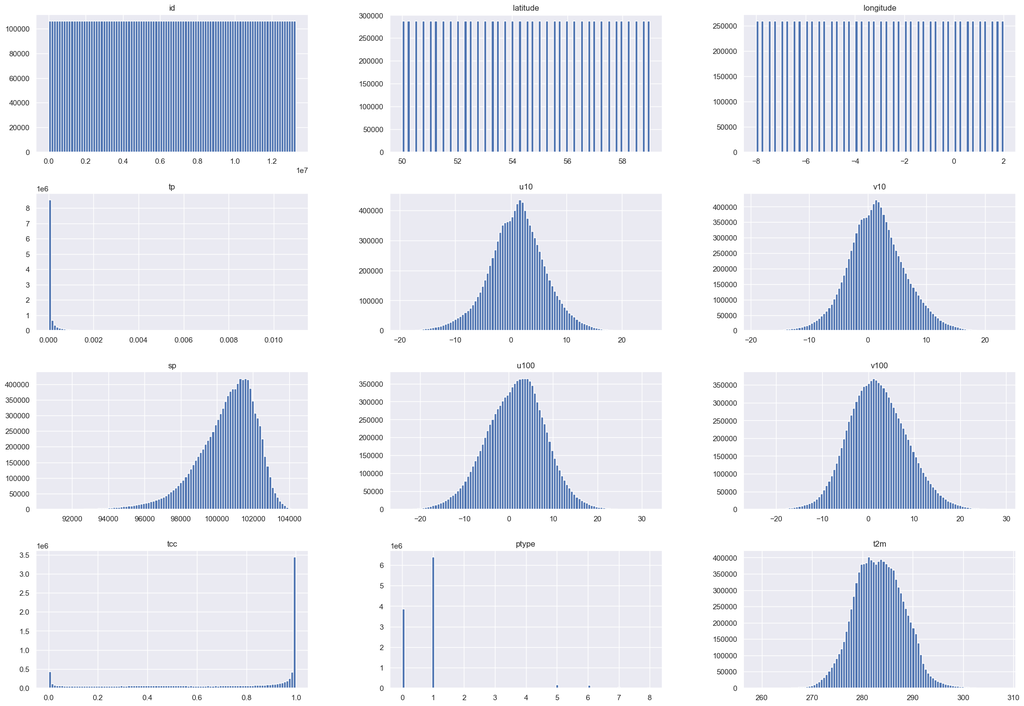

```python
training.hist(figsize = (26,18), bins=100)
plt.show()
```

```python
# check for unique values to see unique identifiers
print(training.info(), '\n\n')

print(training.nunique())
```

```
<class 'pandas.core.frame.DataFrame'>
Index: 10631136 entries, 1 to 13288919
Data columns (total 13 columns):
 #   Column      Dtype
---  ------      -----
 0   id          int64
 1   valid_time  object
 2   latitude    float64
 3   longitude   float64
 4   tp          float64
 5   u10         float64
 6   v10         float64
 7   sp          float64
 8   u100        float64
 9   v100        float64
 10  tcc         float64
 11  ptype       float64
 12  t2m         float64
dtypes: float64(11), int64(1), object(1)
memory usage: 1.1+ GB
None


id            10631136
valid_time        8760
latitude            37
longitude           41
tp               11040
u10            1699709
v10            1601908
sp              177081
u100           2012345
v100           1938677
tcc              32769
ptype                7
t2m             217052
dtype: int64
```

After checking that there was no missing data, and seeing that the only unqiue identifier is id (as expected), we are then able to go on to transforming the data for use in our model.

## Data Transformation

First we have the id column, as this clearly is not of relevance to our weather conditions, we are able to comfortably drop this from our data.

```python
training.drop(['id'], axis=1, inplace=True)
tuning.drop(['id'], axis=1, inplace=True)
testing.drop(['id'], axis=1, inplace=True)

tuning.head()
```

|  | valid_time | latitude | longitude | tp | u10 | v10 | sp | u100 | v100 | tcc | ptype | t2m |
| --- | --- | --- | --- | --- | --- | --- | --- | --- | --- | --- | --- | --- |
| 0 | 2018-01-01 00:00:00 | 59.0 | -8.0 | 0.000004 | 1.405868 | -1.367767 | 98134.81 | 1.516388 | -1.468002 | 0.968842 | 1.0 | 279.75903 |
| 10 | 2018-01-01 00:00:00 | 59.0 | -5.5 | 0.000009 | 3.483993 | -2.736908 | 98042.81 | 3.619904 | -2.961166 | 0.983246 | 1.0 | 280.32935 |
| 20 | 2018-01-01 00:00:00 | 59.0 | -3.0 | 0.000754 | 5.317978 | -6.349213 | 97713.81 | 5.878693 | -7.051987 | 1.000000 | 1.0 | 279.55396 |
| 30 | 2018-01-01 00:00:00 | 59.0 | -0.5 | 0.000247 | 5.092392 | -6.906830 | 97586.81 | 5.570099 | -7.937729 | 0.995575 | 1.0 | 280.05200 |
| 40 | 2018-01-01 00:00:00 | 59.0 | 2.0 | 0.000309 | 6.354111 | 3.703522 | 97446.81 | 7.190216 | 4.038834 | 0.512573 | 1.0 | 280.44458 |

Now we have the time values. As we can see these are currently in a form which our model would not be able to interpret. As this data spans one year, we have no need for this information, the month and day of the year are useful, for a macro and micro scale for annual timing, and while hour will be important for day/night temperature differences, clearly minutes and seconds are unnecessary/unhelpful.

After processing the time values in this way, we can then drop unnecessary rows.

```python
# Split valid_time into month, day of month, hour
training['month'] = training['valid_time'].str.slice(5, 7).astype(int)
training['day_of_month'] = training['valid_time'].str.slice(8, 10).astype(int)
training['hour'] = training['valid_time'].str.slice(11, 13).astype(int)

training.head()

# To make it easier for the model to interpret the cyclic nature of these values, we will encode them as sine and cosine values later.
```

|  | valid_time | latitude | longitude | tp | u10 | v10 | sp | u100 | v100 | tcc | ptype | t2m | month | day_of_month | hour |
| --- | --- | --- | --- | --- | --- | --- | --- | --- | --- | --- | --- | --- | --- | --- | --- |
| 1 | 2018-01-01 00:00:00 | 59.0 | -7.75 | 0.000017 | 2.151962 | -1.555267 | 98086.81 | 2.239044 | -1.634994 | 0.978790 | 1.0 | 279.61255 | 1 | 1 | 0 |
| 2 | 2018-01-01 00:00:00 | 59.0 | -7.50 | 0.000018 | 2.691025 | -1.585541 | 98078.81 | 2.783966 | -1.686752 | 0.975586 | 1.0 | 279.71997 | 1 | 1 | 0 |
| 3 | 2018-01-01 00:00:00 | 59.0 | -7.25 | 0.000019 | 2.850204 | -1.714447 | 98076.81 | 2.971466 | -1.854721 | 0.978790 | 1.0 | 279.78247 | 1 | 1 | 0 |
| 4 | 2018-01-01 00:00:00 | 59.0 | -7.00 | 0.000015 | 3.299423 | -1.867767 | 98084.81 | 3.455841 | -2.001205 | 0.968842 | 1.0 | 279.86646 | 1 | 1 | 0 |
| 6 | 2018-01-01 00:00:00 | 59.0 | -6.50 | 0.000011 | 3.682236 | -2.309174 | 98063.81 | 3.763458 | -2.431869 | 0.967682 | 1.0 | 280.07153 | 1 | 1 | 0 |

```python
# Convert day of month to day of year

def to_year_day(row):
    month = row['month']
    day_of_month = row['day_of_month']
    month_days = [31, 28, 31, 30, 31, 30, 31, 31, 30, 31, 30, 31]
    return int(np.sum(month_days[:month - 1]) + day_of_month)

training['day'] = training.apply(to_year_day, axis=1)
```

```python
# Drop the redundant data

training.drop(['valid_time'], axis=1, inplace=True)
training.drop(['day_of_month'], axis=1, inplace=True)

training.sample(n=10)
```

|  | latitude | longitude | tp | u10 | v10 | sp | u100 | v100 | tcc | ptype | t2m | month | hour | day |
| --- | --- | --- | --- | --- | --- | --- | --- | --- | --- | --- | --- | --- | --- | --- |
| 5555732 | 56.25 | -1.25 | 9.536743e-07 | -1.207169 | 0.428787 | 101781.250 | -1.498932 | 0.448883 | 0.962036 | 1.0 | 285.43872 | 6 | 14 | 153 |
| 9457623 | 55.25 | -0.50 | 0.000000e+00 | 0.558334 | 8.953751 | 100442.190 | 2.178879 | 12.815659 | 0.658630 | 0.0 | 290.37524 | 9 | 18 | 260 |
| 7531288 | 53.75 | 1.75 | 0.000000e+00 | -5.388672 | 3.568771 | 101292.940 | -7.545853 | 6.002091 | 0.006683 | 0.0 | 292.46704 | 7 | 20 | 207 |
| 373668 | 56.25 | 0.75 | 3.232956e-04 | -3.157929 | -1.432083 | 101497.875 | -4.017441 | -1.189804 | 0.971314 | 1.0 | 281.20483 | 1 | 6 | 11 |
| 11715164 | 53.75 | -0.75 | 0.000000e+00 | -3.899246 | -1.408951 | 103007.750 | -8.082001 | -1.999985 | 0.617249 | 0.0 | 280.01978 | 11 | 18 | 322 |
| 6737393 | 56.75 | -1.25 | 0.000000e+00 | 1.658630 | 4.955856 | 101141.250 | 3.937683 | 5.826859 | 0.082184 | 0.0 | 288.32593 | 7 | 1 | 186 |
| 3223769 | 58.25 | -2.75 | 1.525879e-04 | -9.603470 | 2.446213 | 100693.310 | -10.913712 | 2.836105 | 0.514191 | 1.0 | 277.39110 | 3 | 13 | 89 |
| 8202891 | 56.25 | -2.75 | 3.814697e-06 | 4.912399 | 2.487427 | 100758.000 | 6.698166 | 3.216797 | 0.899414 | 1.0 | 288.12036 | 8 | 7 | 226 |
| 7132202 | 54.25 | -6.50 | 5.497932e-04 | 1.194092 | 3.190781 | 100009.750 | 2.538284 | 5.569824 | 1.000000 | 1.0 | 290.17310 | 7 | 21 | 196 |
| 6929707 | 58.75 | -5.50 | 1.583099e-04 | 2.429199 | -1.135529 | 102752.500 | 2.835602 | -1.399750 | 1.000000 | 1.0 | 286.41162 | 7 | 8 | 191 |

Looking at the distribution of the target data set and the boxplot against month, we see how time of year and temperature clearly relate. Additionally, by looking at the same comparison of time of day, we see how temperature and time of day are clearly linked - with hotter days and cooler nights.

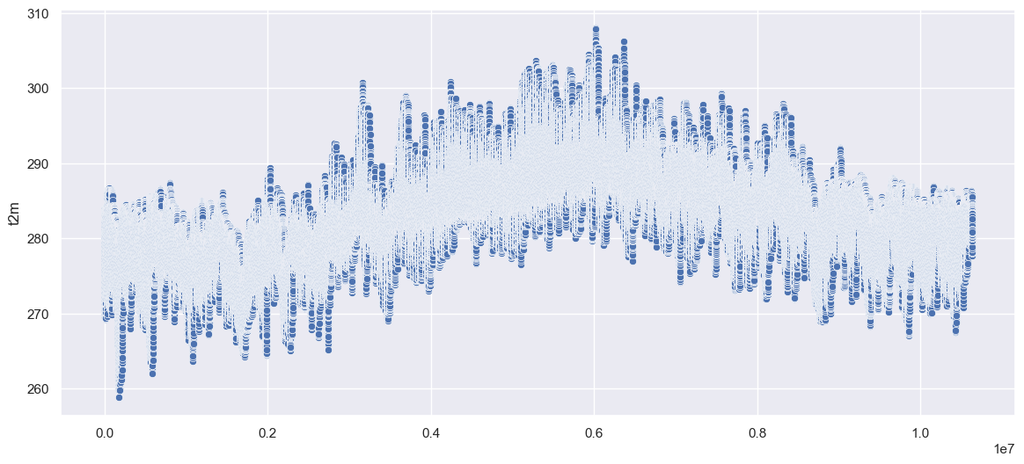

```python
sns.scatterplot(x=list(range(target_training.shape[0])), y=target_training)
```

Next we examine the temperatures by month and notice that like the general data plot above, but grouped by month the data follows an expected seasonal pattern of Winter months at the coldest into a hotter Summer.

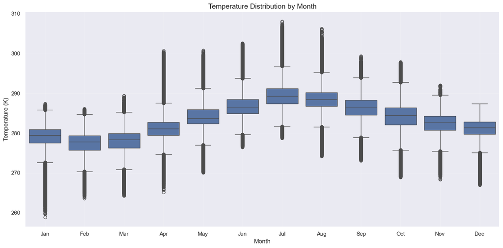

```python
# Temperature distribution by month boxplot
plt.figure(figsize=(14, 7))
sns.boxplot(x=training['month'], y=target_training)
plt.title('Temperature Distribution by Month', fontsize=14)
plt.xlabel('Month')
plt.ylabel('Temperature (K)')
plt.xticks(range(12), ['Jan', 'Feb', 'Mar', 'Apr', 'May', 'Jun', 'Jul', 'Aug', 'Sep', 'Oct', 'Nov', 'Dec'])
plt.grid(True, alpha=0.2)
plt.tight_layout()
plt.show()
```

We also see an expected cyclic temperature profile where the temperature cools during the night and warms until a peak in the afternoon. It will be important to make sure the models are easily able to interpret this cyclic behaviour.

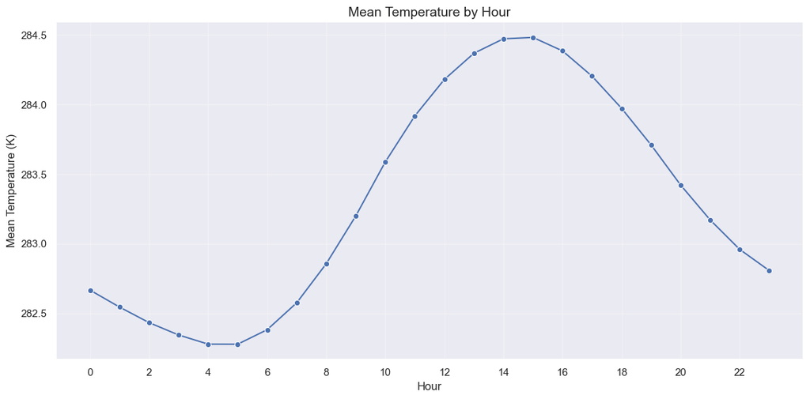

```python
# Mean temperature by hour
hourly_temp = training.groupby('hour')['t2m'].mean().reset_index()

plt.figure(figsize=(12, 6))
sns.lineplot(x='hour', y='t2m', data=hourly_temp, marker='o')
plt.title('Mean Temperature by Hour', fontsize=14)
plt.xlabel('Hour')
plt.ylabel('Mean Temperature (K)')
plt.xticks(range(0, 24, 2))  # Show every 2 hours
plt.grid(True, alpha=0.3)
plt.tight_layout()
plt.show()
```

The next two columns are latitude and longitude which we preserve in their current form (but will use standard scaling on later). We see these are good predictors of temperature when taken together.

Then, we have the total precipitation value which we see is already nicely ready for use and has an exponentially decreasing occurence rate for with peak at 0:

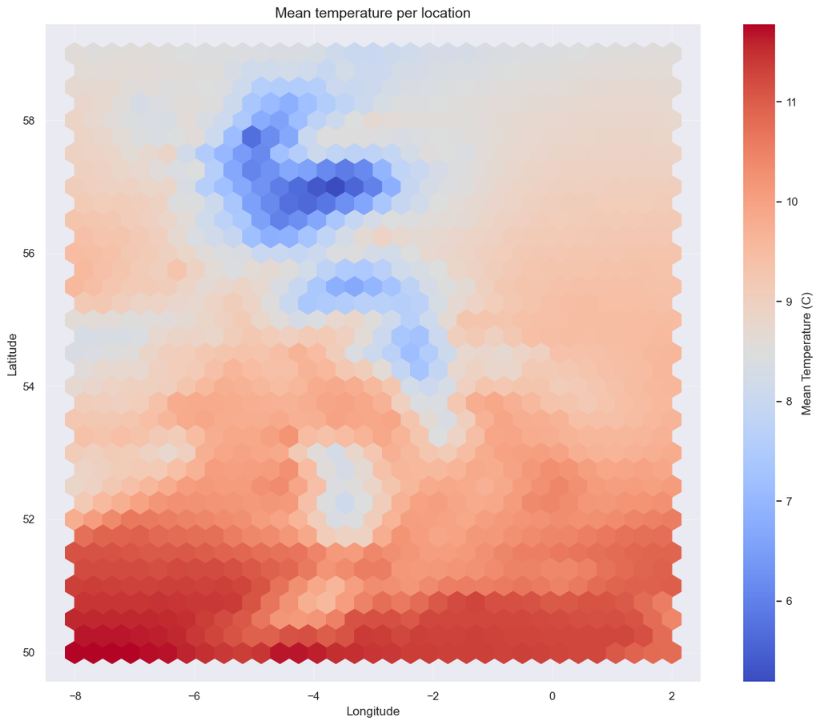

```python
# mean temperature distribution by location
plt.figure(figsize=(12, 10))
hb = plt.hexbin(
    training['longitude'],
    training['latitude'],
    C=target_training - 274,
    gridsize=32,
    cmap='coolwarm',
    reduce_C_function=np.mean,
    mincnt=1
)

plt.colorbar(hb, label='Mean Temperature (C)')
plt.grid(True, alpha=0.3)
plt.title('Mean temperature per location', fontsize=14)
plt.xlabel('Longitude')
plt.ylabel('Latitude')
plt.tight_layout()
plt.show()
```

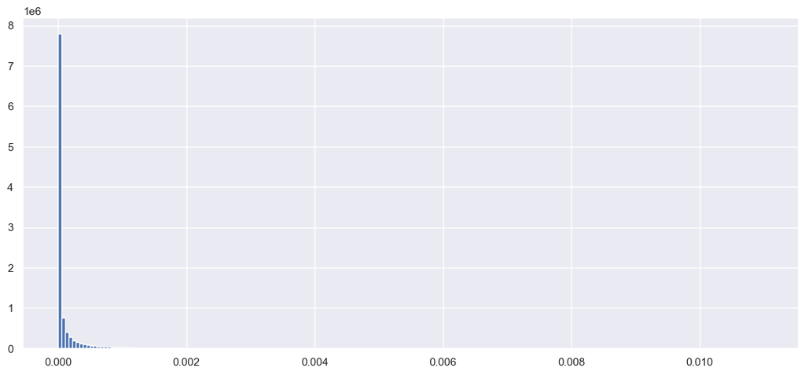

```python
training['tp'].hist(bins=200)
```

Now, we have to consider the u10 and v10 values. For this, we look at the cross correlations values.

Here we see that the u10 and v10 are extremely closely correlated to the values for u100 and v100. As such, we will drop these values from our final model. While this does relate differently to wind shear, when compared to u100 and v100, we still chose to omit the values as redundant.

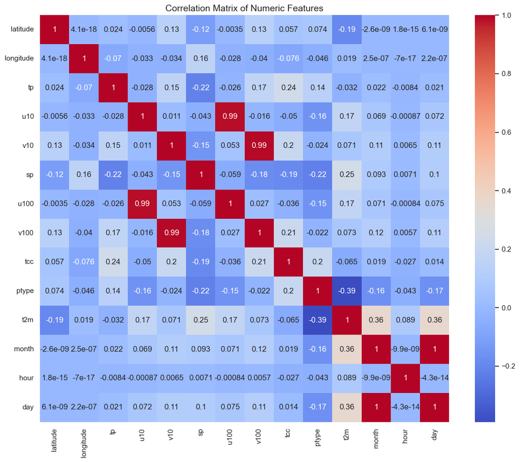

```python
# correlation matrix for numeric features
correlations = training.corr(numeric_only=True)

plt.figure(figsize=(12, 10))
sns.heatmap(correlations, annot=True, cmap='coolwarm')
plt.title('Correlation Matrix of Numeric Features', fontsize=14)
plt.tight_layout()
plt.show()
```

The next values are for surface pressure which we simply rescale using standard scaler. We see that this has a good correlation to temperature from both the plot of binned pressure values and the cross correlation values.

Then, we keep both u100 and v100 as they represent the wind velocity components. While we will keep these values and scale with standard scaler, we will also derive wind speed and direction as these correlate with temperature (northerly winds tend to bring colder arctic air while southernly bring hot equatorial air) later in our data engineering.

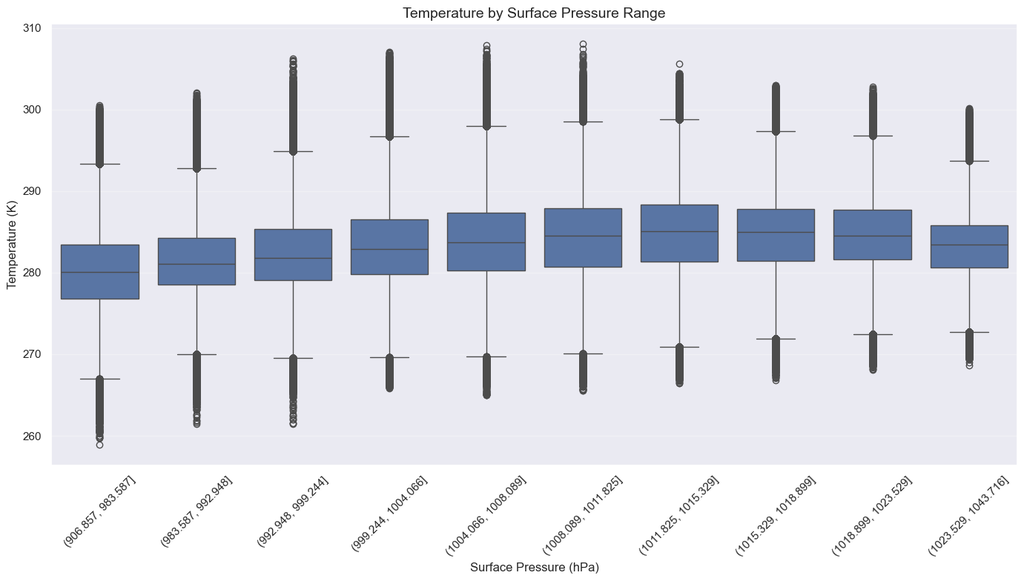

```python
# surface pressure (sp) vs temperature (t2m)
pressure_bins = pd.qcut(training['sp'] * 0.01, q=10, duplicates='drop')

plt.figure(figsize=(14, 8))
sns.boxplot(x=pressure_bins, y='t2m', data=training)
plt.title('Temperature by Surface Pressure Range', fontsize=14)
plt.xlabel('Surface Pressure (hPa)')
plt.ylabel('Temperature (K)')
plt.xticks(rotation=45)
plt.grid(True, alpha=0.3, axis='y')
plt.tight_layout()
plt.show()
```

We see that while the wind speed along each axis appears to primarily drive the temperature correlations, there is also some dependency on direction. Thus, we come to the conclusion that we should add separate categories for net wind speed and direction in engineering.

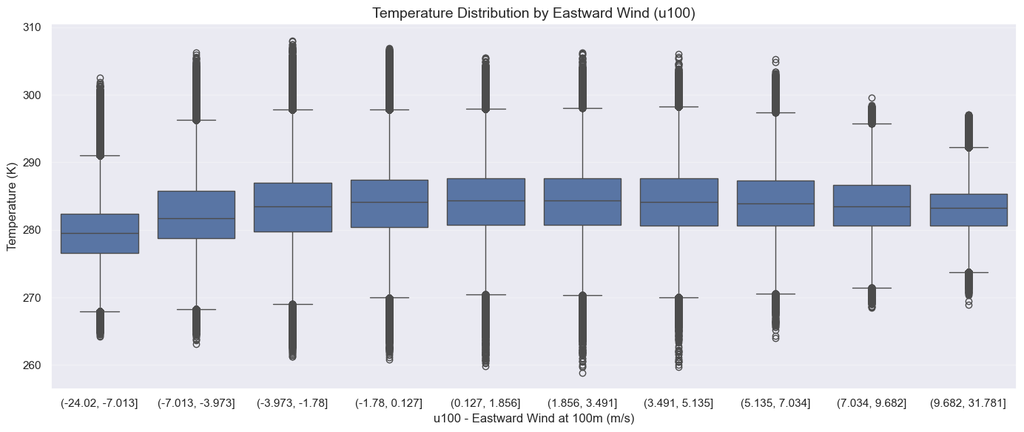

```python
# Eastward wind (u100) vs temperature (t2m)
u100_bins = pd.qcut(training['u100'], q=10, duplicates='drop')

plt.figure(figsize=(14, 6))
sns.boxplot(x=u100_bins, y='t2m', data=training)
plt.title('Temperature Distribution by Eastward Wind (u100)', fontsize=14)
plt.xlabel('u100 - Eastward Wind at 100m (m/s)')
plt.ylabel('Temperature (K)')
plt.grid(True, alpha=0.3, axis='y')
plt.tight_layout()
plt.show()
```

[figure not shown]

```python
# Northward wind (v100) vs temperature (t2m)
v100_bins = pd.qcut(training['v100'], q=10, duplicates='drop')

plt.figure(figsize=(14, 6))
sns.boxplot(x=u100_bins, y='t2m', data=training)
plt.title('Temperature Distribution by Northward Wind (v100)', fontsize=14)
plt.xlabel('v100 - Northward Wind at 100m (m/s)')
plt.ylabel('Temperature (K)')
plt.grid(True, alpha=0.3, axis='y')
plt.tight_layout()
plt.show()
```

Total cloud cover is now our next column and this is simplified by already being in a 0-1 format that is perfect for our model. As such, we simply treat this with standard scaler and continue.

IFS Precipitation Types:

- 0 - No Precipitation
- 1 - Rain
- 3 - Freezing Rain
- 5 - Snow
- 6 - Wet Snow
- 7 - Mixture of Rain and Snow
- 8 - Ice Pellets
- 12 - Freezing Drizzle

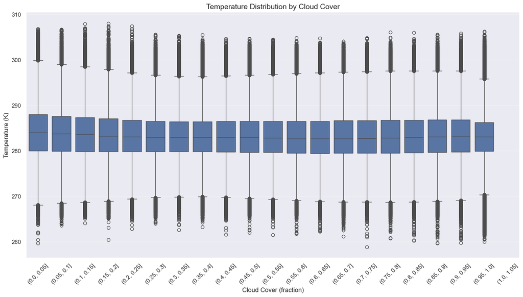

```python
# Cloud cover (tcc) vs temperature (t2m)
bins = np.arange(0, 1.1, 0.05)
cloud_category = pd.cut(training['tcc'], bins=bins)

plt.figure(figsize=(14, 8))
sns.boxplot(x=cloud_category, y='t2m', data=training)
plt.title('Temperature Distribution by Cloud Cover', fontsize=14)
plt.xlabel('Cloud Cover (fraction)')
plt.ylabel('Temperature (K)')
plt.xticks(rotation=45)
plt.grid(True, alpha=0.3, axis='y')
plt.tight_layout()
plt.show()
```

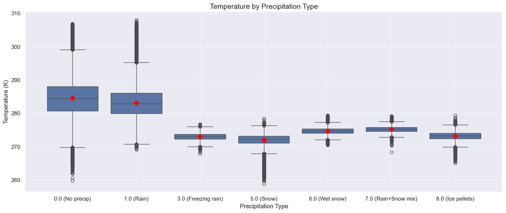

```python
# precipitation type (ptype) vs temperature (t2m)
plt.figure(figsize=(14, 6))
sns.boxplot(x='ptype', y='t2m', data=training)

means = training.groupby('ptype')['t2m'].mean()
for i, mean_val in enumerate(means):
    plt.scatter(i, mean_val, marker='D', color='red', s=50, zorder=3)

plt.title('Temperature by Precipitation Type', fontsize=14)
plt.xlabel('Precipitation Type')
plt.ylabel('Temperature (K)')

ptype_labels = {
    0: 'No precip',
    1: 'Rain',
    3: 'Freezing rain',
    5: 'Snow',
    6: 'Wet snow',
    7: 'Rain+Snow mix',
    8: 'Ice pellets',
    12: 'Freezing drizzle'
}

present_types = sorted(training['ptype'].unique())
plt.xticks(range(len(present_types)),
        [f"{t} ({ptype_labels.get(t, 'Unknown')})" for t in present_types])

plt.grid(True, alpha=0.3)
plt.tight_layout()
plt.show()
```

While there is some redundancy with the no precipitation value here and the total precipitation having a value of 0, we have decided to keep both columns. As precipitation type is clearly a strong indicator of temperature as seen above, and also we decided that the volume of precipitation is too important to reduce to a boolean value.

We now change the ordering of the precipitation type values to better understand the data, with precipitation types requiring colder temps (referencing online sources) at higher values.

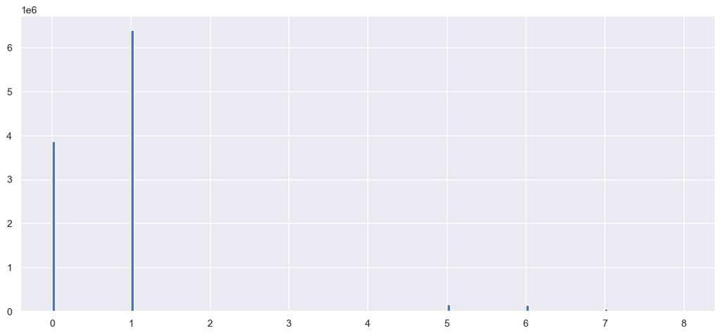

```
ptype
1.0    6400254
0.0    3860282
5.0     159765
6.0     137913
7.0      49528
8.0      18595
3.0       4799
Name: count, dtype: int64
```

```python
training['ptype'].hist(bins=200)
plt.show()

training['ptype'].value_counts()
```

```python
# Define a reordering function

def reorder_ptype(row):
    if row['ptype'] == 0:
        return 0
    elif row['ptype'] == 1:
        return 1
    elif row['ptype'] == 3:
        return 2
    elif row['ptype'] == 12: # While there is no occurence of freezing drizzle in our training data, it can appear in test data
        return 3
    elif row['ptype'] == 7:
        return 4
    elif row['ptype'] == 6:
        return 5
    elif row['ptype'] == 8:
        return 6
    elif row['ptype'] == 5:
        return 7


training['ordered_ptype'] = training.apply(reorder_ptype, axis=1)
```

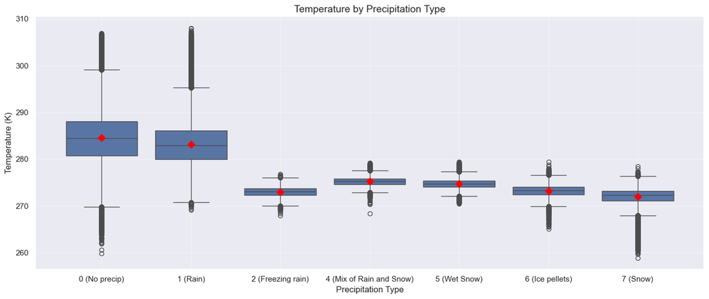

```python
# precipitation type (ptype) vs temperature (t2m)
plt.figure(figsize=(14, 6))
sns.boxplot(x='ordered_ptype', y='t2m', data=training)

means = training.groupby('ordered_ptype')['t2m'].mean()
for i, mean_val in enumerate(means):
    plt.scatter(i, mean_val, marker='D', color='red', s=50, zorder=3)

plt.title('Temperature by Precipitation Type', fontsize=14)
plt.xlabel('Precipitation Type')
plt.ylabel('Temperature (K)')

ptype_labels = {
    0: 'No precip',
    1: 'Rain',
    2: 'Freezing rain',
    3: 'Freezing drizzle',
    4: 'Mix of Rain and Snow',
    5: 'Wet Snow',
    6: 'Ice pellets',
    7: 'Snow'
}

present_types = sorted(training['ordered_ptype'].unique())
plt.xticks(range(len(present_types)),
        [f"{t} ({ptype_labels.get(t, 'Unknown')})" for t in present_types])

plt.grid(True, alpha=0.3)
plt.tight_layout()
plt.show()
```

```python
training.sample(n=10)
```

|  | latitude | longitude | tp | u10 | v10 | sp | u100 | v100 | tcc | ptype | t2m | month | hour | day | ordered_ptype |
| --- | --- | --- | --- | --- | --- | --- | --- | --- | --- | --- | --- | --- | --- | --- | --- |
| 2950476 | 50.50 | 0.50 | 0.000003 | 5.517273 | 7.960938 | 101254.250 | 6.826096 | 9.408783 | 0.797516 | 0.0 | 280.36768 | 3 | 0 | 82 | 0 |
| 8605903 | 50.00 | -7.25 | 0.000000 | 2.306198 | -4.833618 | 101910.940 | 2.472504 | -5.110855 | 0.905029 | 0.0 | 287.66003 | 8 | 8 | 237 | 0 |
| 3091518 | 50.75 | 1.00 | 0.000000 | 3.841873 | 1.821854 | 101767.125 | 5.541657 | 1.842606 | 0.776092 | 0.0 | 280.69970 | 3 | 21 | 85 | 0 |
| 3475788 | 57.00 | -4.75 | 0.000029 | -3.384232 | 5.189789 | 95471.440 | -4.800171 | 7.548340 | 1.000000 | 1.0 | 279.16820 | 4 | 11 | 96 | 1 |
| 5016077 | 53.75 | -4.50 | 0.000000 | 1.590134 | 0.357651 | 102514.440 | 2.705597 | 1.394821 | 0.212097 | 0.0 | 283.52856 | 5 | 18 | 138 | 0 |
| 11256278 | 58.25 | -4.25 | 0.000000 | -1.950836 | 2.643387 | 97283.940 | -3.337311 | 5.932709 | 1.000000 | 1.0 | 280.54785 | 11 | 4 | 310 | 1 |
| 6630141 | 54.00 | -0.25 | 0.000000 | -3.100800 | -1.504562 | 101528.690 | -5.872253 | -1.023178 | 0.556488 | 0.0 | 286.46436 | 7 | 2 | 183 | 0 |
| 2622448 | 52.50 | -6.50 | 0.000021 | -3.572403 | 8.012375 | 99205.625 | -5.213837 | 12.740723 | 1.000000 | 1.0 | 281.61646 | 3 | 0 | 73 | 1 |
| 1381002 | 56.00 | 2.00 | 0.000000 | 5.967194 | 5.358505 | 101608.940 | 6.557098 | 5.824707 | 0.590759 | 0.0 | 277.69897 | 2 | 22 | 38 | 0 |
| 12173309 | 53.75 | 2.00 | 0.000035 | 5.216187 | 7.180573 | 100591.750 | 5.986816 | 8.155930 | 0.903320 | 1.0 | 282.25977 | 12 | 8 | 335 | 1 |

## Data Cleaning

Here we drop the columns that we won't want to feed into our model

```python
training.drop(['t2m'], axis=1, inplace=True)

training.drop(['u10'], axis=1, inplace=True)
training.drop(['v10'], axis=1, inplace=True)

training.drop(['ptype'], axis=1, inplace=True)
```

```python
training.head()
```

|  | latitude | longitude | tp | sp | u100 | v100 | tcc | month | hour | day | ordered_ptype |
| --- | --- | --- | --- | --- | --- | --- | --- | --- | --- | --- | --- |
| 1 | 59.0 | -7.75 | 0.000017 | 98086.81 | 2.239044 | -1.634994 | 0.978790 | 1 | 0 | 1 | 1 |
| 2 | 59.0 | -7.50 | 0.000018 | 98078.81 | 2.783966 | -1.686752 | 0.975586 | 1 | 0 | 1 | 1 |
| 3 | 59.0 | -7.25 | 0.000019 | 98076.81 | 2.971466 | -1.854721 | 0.978790 | 1 | 0 | 1 | 1 |
| 4 | 59.0 | -7.00 | 0.000015 | 98084.81 | 3.455841 | -2.001205 | 0.968842 | 1 | 0 | 1 | 1 |
| 6 | 59.0 | -6.50 | 0.000011 | 98063.81 | 3.763458 | -2.431869 | 0.967682 | 1 | 0 | 1 | 1 |

Now we change the time values to sinusoidal forms so that the model can better interpret the data

```python
training['month_sin'] = np.sin(2 * np.pi * training['month']/12)
training['month_cos'] = np.cos(2 * np.pi * training['month']/12)
training['day_sin'] = np.sin(2 * np.pi * training['day']/365)
training['day_cos'] = np.cos(2 * np.pi * training['day']/365)
training['hour_sin'] = np.sin(2 * np.pi * training['hour']/24)
training['hour_cos'] = np.cos(2 * np.pi * training['hour']/24)

training.sample(10)
```

|  | latitude | longitude | tp | sp | u100 | v100 | tcc | month | hour | day | ordered_ptype | month_sin | month_cos | day_sin | day_cos | hour_sin | hour_cos |
| --- | --- | --- | --- | --- | --- | --- | --- | --- | --- | --- | --- | --- | --- | --- | --- | --- | --- |
| 13077278 | 54.50 | -8.00 | 0.000002 | 100745.810 | 1.700424 | 6.952622 | 0.786652 | 12 | 4 | 360 | 1 | -2.449294e-16 | 1.000000e+00 | -0.085965 | 0.996298 | 0.866025 | 5.000000e-01 |
| 1648772 | 51.25 | 1.75 | 0.000001 | 100409.750 | 8.118393 | 6.205322 | 0.991974 | 2 | 6 | 46 | 1 | 8.660254e-01 | 5.000000e-01 | 0.711657 | 0.702527 | 1.000000 | 6.123234e-17 |
| 11850483 | 51.75 | -6.25 | 0.000059 | 101408.750 | -13.103699 | 4.498138 | 0.983551 | 11 | 11 | 326 | 1 | -5.000000e-01 | 8.660254e-01 | -0.622047 | 0.782980 | 0.258819 | -9.659258e-01 |
| 2018252 | 55.25 | -1.25 | 0.000000 | 103185.690 | -5.756760 | 6.046890 | 0.899628 | 2 | 10 | 56 | 0 | 8.660254e-01 | 5.000000e-01 | 0.821477 | 0.570242 | 0.500000 | -8.660254e-01 |
| 11757747 | 53.00 | -4.75 | 0.000007 | 101756.310 | -9.407486 | -4.256943 | 0.591797 | 11 | 22 | 323 | 1 | -5.000000e-01 | 8.660254e-01 | -0.661635 | 0.749826 | -0.500000 | 8.660254e-01 |
| 9279874 | 56.75 | -4.00 | 0.000051 | 95929.310 | 5.532379 | 4.720139 | 1.000000 | 9 | 21 | 255 | 1 | -1.000000e+00 | -1.836970e-16 | -0.948362 | -0.317191 | -0.707107 | 7.071068e-01 |
| 11999217 | 51.50 | 0.50 | 0.000067 | 100834.060 | -1.431900 | -4.659180 | 0.921631 | 11 | 13 | 330 | 1 | -5.000000e-01 | 8.660254e-01 | -0.566702 | 0.823923 | -0.258819 | -9.659258e-01 |
| 7571372 | 59.00 | -1.75 | 0.000000 | 100870.875 | -10.768036 | 11.309998 | 0.509888 | 7 | 23 | 208 | 0 | -5.000000e-01 | -8.660254e-01 | -0.425000 | -0.905193 | -0.258819 | 9.659258e-01 |
| 9262442 | 52.00 | -5.75 | 0.000000 | 102477.440 | 3.676117 | -3.639236 | 0.061523 | 9 | 9 | 255 | 0 | -1.000000e+00 | -1.836970e-16 | -0.948362 | -0.317191 | 0.707107 | -7.071068e-01 |
| 1027802 | 54.25 | -4.50 | 0.001972 | 101542.500 | 10.204666 | -5.042755 | 1.000000 | 1 | 5 | 29 | 1 | 5.000000e-01 | 8.660254e-01 | 0.478734 | 0.877960 | 0.965926 | 2.588190e-01 |

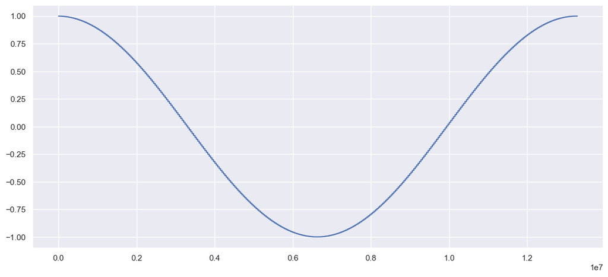

```python
plt.plot(training['day_cos'])
```

## Data Engineering

Here we want to implement a few new feeatures:

```python
training['wind_speed'] = np.sqrt(training['u100']**2 + training['v100']**2)
training['wind_direction'] = np.arctan2(training['v100'], training['u100']) # In radians

# Convert wind direction to sine and cosine to better interpret spatial reality

training['wind_direction_sin'] = np.sin(training['wind_direction'])
training['wind_direction_cos'] = np.cos(training['wind_direction'])

training.head()
```

|  | latitude | longitude | tp | sp | u100 | v100 | tcc | month | hour | day | ... | month_sin | month_cos | day_sin | day_cos | hour_sin | hour_cos | wind_speed | wind_direction | wind_direction_sin | wind_direction_cos |
| --- | --- | --- | --- | --- | --- | --- | --- | --- | --- | --- | --- | --- | --- | --- | --- | --- | --- | --- | --- | --- | --- |
| 1 | 59.0 | -7.75 | 0.000017 | 98086.81 | 2.239044 | -1.634994 | 0.978790 | 1 | 0 | 1 | ... | 0.5 | 0.866025 | 0.017213 | 0.999852 | 0.0 | 1.0 | 2.772458 | -0.630721 | -0.589727 | 0.807602 |
| 2 | 59.0 | -7.50 | 0.000018 | 98078.81 | 2.783966 | -1.686752 | 0.975586 | 1 | 0 | 1 | ... | 0.5 | 0.866025 | 0.017213 | 0.999852 | 0.0 | 1.0 | 3.255088 | -0.544733 | -0.518189 | 0.855266 |
| 3 | 59.0 | -7.25 | 0.000019 | 98076.81 | 2.971466 | -1.854721 | 0.978790 | 1 | 0 | 1 | ... | 0.5 | 0.866025 | 0.017213 | 0.999852 | 0.0 | 1.0 | 3.502799 | -0.558007 | -0.529497 | 0.848312 |
| 4 | 59.0 | -7.00 | 0.000015 | 98084.81 | 3.455841 | -2.001205 | 0.968842 | 1 | 0 | 1 | ... | 0.5 | 0.866025 | 0.017213 | 0.999852 | 0.0 | 1.0 | 3.993452 | -0.524894 | -0.501122 | 0.865377 |
| 6 | 59.0 | -6.50 | 0.000011 | 98063.81 | 3.763458 | -2.431869 | 0.967682 | 1 | 0 | 1 | ... | 0.5 | 0.866025 | 0.017213 | 0.999852 | 0.0 | 1.0 | 4.480804 | -0.573685 | -0.542731 | 0.839907 |

5 rows × 21 columns

```python
# Lon/lat ranges:

print(f"Longitude ranges from {np.min(training['longitude']): .2f} to {np.max(training['longitude']): .2f}")
print(f"Latitude ranges from {np.min(training['latitude']): .2f} to {np.max(training['latitude']): .2f}")
print('Each in 0.25 increments.')

print(training.nunique())
```

```
Longitude ranges from -8.00 to  2.00
Latitude ranges from  50.00 to  59.00
Each in 0.25 increments.
latitude                    37
longitude                   41
tp                       11040
sp                      177081
u100                   2012345
v100                   1938677
tcc                      32769
month                       12
hour                        24
day                        365
ordered_ptype                7
month_sin                   11
month_cos                   11
day_sin                    365
day_cos                    338
hour_sin                    22
hour_cos                    22
wind_speed            10630802
wind_direction        10630911
wind_direction_sin    10630902
wind_direction_cos    10630862
dtype: int64
```

Having looked at taking UK Climate Districts as defined by the UK's MET Office or simply nearby grids, we have found the grids to give a better indication of temperature.

```python
# Define locale
def locale_sorter(row):
    return (8 + row['longitude'] - (row['longitude'] % 2)) / 2 + 6 * ((-50 + row['latitude'] - (row['latitude'] % 2)) / 2)

training['locale'] = training.apply(locale_sorter, axis=1)

# Group-based averages using transform
training['local_wind_speed'] = training.groupby(['day', 'hour', 'locale'])['wind_speed'].transform('mean')

training['local_precipitation'] = training.groupby(['day', 'hour', 'locale'])['tp'].transform('mean')

training['absolute_hour'] = 24 * training['day'] + training['hour']
```

```python
training.info()
```

```
<class 'pandas.core.frame.DataFrame'>
Index: 10631136 entries, 1 to 13288919
Data columns (total 25 columns):
 #   Column               Dtype
---  ------               -----
 0   latitude             float64
 1   longitude            float64
 2   tp                   float64
 3   sp                   float64
 4   u100                 float64
 5   v100                 float64
 6   tcc                  float64
 7   month                int64
 8   hour                 int64
 9   day                  int64
```

[output cut: 17 more lines]

```python
# This is a finalised vesrsion of this method which removes duplication in the merging set to prevent row explosion

# Create a shifted version of the training DataFrame
training_shifted = training.copy()
training_shifted['absolute_hour'] += 1  # Shift forward so current hour matches previous data
training_shifted = training_shifted[['absolute_hour', 'locale', 'local_wind_speed', 'local_precipitation']]

# Aggregate duplicates by taking mean of local_wind_speed and local_precipitation
training_shifted = training_shifted.groupby(['absolute_hour', 'locale'], as_index=False).agg({
    'local_wind_speed': 'mean',
    'local_precipitation': 'mean'
})

training_shifted.rename(columns={'local_wind_speed': 'historic_local_wind_speed'}, inplace=True)
training_shifted.rename(columns={'local_precipitation': 'historic_local_precipitation'}, inplace=True)

# Merge the DataFrames on absolute_hour and locale
training = training.merge(
    training_shifted,
    on=['absolute_hour', 'locale'],
    how='left'
)
```

```python
training.sample(n=20, random_state=12)
```

|  | latitude | longitude | tp | sp | u100 | v100 | tcc | month | hour | day | ... | wind_speed | wind_direction | wind_direction_sin | wind_direction_cos | locale | local_wind_speed | local_precipitation | absolute_hour | historic_local_wind_speed | historic_local_precipitation |
| --- | --- | --- | --- | --- | --- | --- | --- | --- | --- | --- | --- | --- | --- | --- | --- | --- | --- | --- | --- | --- | --- |
| 3988292 | 56.00 | -5.00 | 0.000000e+00 | 100862.440 | 0.785004 | 1.925674 | 0.976746 | 5 | 22 | 137 | ... | 2.079532 | 1.183711 | 0.926013 | 0.377491 | 19.0 | 2.825825 | 0.000000e+00 | 3310 | 2.522283 | 0.000000e+00 |
| 8290363 | 57.25 | 2.00 | 1.114368e-03 | 100250.690 | -4.092056 | 20.961197 | 1.000000 | 10 | 15 | 285 | ... | 21.356889 | 1.763592 | 0.981472 | -0.191604 | 23.0 | 21.293753 | 1.024791e-03 | 6855 | 20.106434 | 4.333655e-04 |
| 6357495 | 54.00 | -7.25 | 0.000000e+00 | 99724.060 | 3.633438 | 3.055969 | 0.996674 | 8 | 6 | 219 | ... | 4.747717 | 0.699286 | 0.643671 | 0.765302 | 12.0 | 6.410921 | 2.055075e-05 | 5262 | 6.228890 | 2.040115e-05 |
| 4305420 | 53.25 | 0.50 | 1.907349e-06 | 102034.440 | -3.128403 | -8.727859 | 0.663391 | 5 | 19 | 148 | ... | 9.271593 | -1.914969 | -0.941355 | -0.337418 | 10.0 | 8.118469 | 5.422854e-07 | 3571 | 7.822823 | 9.720142e-07 |
| 8317217 | 56.00 | -0.75 | 3.681183e-04 | 99790.940 | 4.529526 | 20.407028 | 1.000000 | 10 | 13 | 286 | ... | 20.903669 | 1.352378 | 0.976241 | 0.216686 | 21.0 | 8.284824 | 2.681650e-03 | 6877 | 7.909967 | 2.519703e-03 |
| 8520628 | 50.25 | -5.25 | 0.000000e+00 | 102820.440 | -1.335205 | 1.389709 | 0.322540 | 10 | 12 | 293 | ... | 1.927191 | 2.336195 | 0.721106 | -0.692824 | 1.0 | 3.862394 | 1.121970e-07 | 7044 | 3.523909 | 2.200787e-07 |
| 2535714 | 55.25 | -4.25 | 0.000000e+00 | 96565.250 | -1.222504 | 1.392166 | 0.777679 | 3 | 1 | 88 | ... | 1.852739 | 2.291397 | 0.751410 | -0.659836 | 13.0 | 3.896821 | 1.632466e-05 | 2113 | 3.398779 | 6.245632e-06 |
| 1621534 | 57.75 | -7.75 | 0.000000e+00 | 102853.750 | -5.028046 | 9.383942 | 0.349274 | 2 | 16 | 56 | ... | 10.646108 | 2.062683 | 0.881443 | -0.472290 | 18.0 | 10.188265 | 0.000000e+00 | 1360 | 10.396137 | 0.000000e+00 |
| 2299505 | 52.00 | 1.00 | 0.000000e+00 | 102743.560 | 0.316376 | -5.824890 | 0.609070 | 3 | 22 | 79 | ... | 5.833476 | -1.516535 | -0.998528 | 0.054235 | 10.0 | 5.170581 | 2.879363e-06 | 1918 | 6.177405 | 1.813851e-06 |
| 3180322 | 53.75 | -7.50 | 0.000000e+00 | 101350.750 | 4.934906 | 3.526138 | 0.255859 | 4 | 4 | 110 | ... | 6.065225 | 0.620411 | 0.581370 | 0.813639 | 6.0 | 5.185713 | 0.000000e+00 | 2644 | 5.142864 | 0.000000e+00 |
| 5842189 | 50.50 | -2.50 | 0.000000e+00 | 101009.250 | 3.904511 | -1.348709 | 0.414124 | 7 | 13 | 201 | ... | 4.130886 | -0.332592 | -0.326494 | 0.945199 | 2.0 | 5.002182 | 1.727618e-05 | 4837 | 4.593429 | 2.745086e-05 |
| 229675 | 56.75 | -5.00 | 1.907349e-06 | 97111.810 | -7.024170 | 4.816940 | 0.826813 | 1 | 21 | 8 | ... | 8.517152 | 2.540483 | 0.565558 | -0.824709 | 19.0 | 9.349659 | 1.109563e-06 | 213 | 9.284739 | 4.674874e-07 |
| 7377845 | 56.25 | -4.75 | 6.628037e-05 | 97096.810 | 9.413345 | 1.187668 | 0.669189 | 9 | 7 | 254 | ... | 9.487972 | 0.125505 | 0.125176 | 0.992135 | 19.0 | 10.770833 | 3.855137e-04 | 6103 | 11.161328 | 5.282514e-04 |
| 7856142 | 55.25 | -2.50 | 9.536743e-07 | 99361.875 | 3.158798 | -5.267365 | 0.826569 | 9 | 17 | 270 | ... | 6.141916 | -1.030603 | -0.857609 | 0.514302 | 14.0 | 7.364868 | 5.382758e-06 | 6497 | 7.827296 | 1.636505e-05 |
| 4160546 | 56.75 | 1.50 | 0.000000e+00 | 102932.125 | -3.446182 | -1.497711 | 1.000000 | 5 | 20 | 143 | ... | 3.757567 | -2.731619 | -0.398585 | -0.917131 | 22.0 | 3.476735 | 5.912781e-07 | 3452 | 3.400730 | 3.943076e-07 |
| 1909990 | 51.50 | -3.75 | 8.296967e-05 | 98396.875 | 7.552780 | 2.826813 | 0.102112 | 3 | 13 | 66 | ... | 8.064450 | 0.358134 | 0.350528 | 0.936552 | 2.0 | 8.621251 | 2.799584e-05 | 1597 | 8.365090 | 1.269696e-05 |
| 9876000 | 52.00 | -2.00 | 0.000000e+00 | 99880.875 | 6.417175 | 2.738556 | 0.992889 | 12 | 1 | 340 | ... | 6.977093 | 0.403355 | 0.392507 | 0.919749 | 9.0 | 7.074545 | 2.150442e-07 | 8161 | 6.820086 | 5.796844e-07 |
| 4244052 | 58.50 | 0.75 | 0.000000e+00 | 103096.875 | -4.479950 | -7.654022 | 0.350739 | 5 | 17 | 146 | ... | 8.868709 | -2.100342 | -0.863037 | -0.505141 | 28.0 | 9.135581 | 0.000000e+00 | 3521 | 9.194599 | 0.000000e+00 |
| 2984499 | 57.25 | 0.50 | 5.779266e-04 | 100966.940 | -13.317505 | 1.338776 | 1.000000 | 4 | 11 | 103 | ... | 13.384628 | 3.041402 | 0.100023 | -0.994985 | 22.0 | 12.992222 | 6.209429e-04 | 2483 | 13.792041 | 3.034782e-04 |
| 5929202 | 53.25 | -4.25 | 7.629395e-06 | 100370.690 | 3.641098 | 7.018875 | 0.950073 | 7 | 13 | 204 | ... | 7.907098 | 1.092255 | 0.887668 | 0.460485 | 7.0 | 9.287310 | 5.197525e-05 | 4909 | 8.838810 | 8.657867e-05 |

20 rows × 27 columns

```python
print(training.info())
```

```
<class 'pandas.core.frame.DataFrame'>
RangeIndex: 10631136 entries, 0 to 10631135
Data columns (total 27 columns):
 #   Column                        Dtype
---  ------                        -----
 0   latitude                      float64
 1   longitude                     float64
 2   tp                            float64
 3   sp                            float64
 4   u100                          float64
 5   v100                          float64
 6   tcc                           float64
 7   month                         int64
 8   hour                          int64
 9   day                           int64
```

[output cut: 20 more lines]

## Create Pipeline

```python
# Scale numeric factors

scaler = StandardScaler()

numerical_attributes = ['month_sin', 'month_cos', 'day_sin', 'day_cos', 'hour_sin', 'hour_cos', 'latitude', 'longitude', 'tp', 'sp', 'u100', 'v100', 'tcc', 'ordered_ptype', 'wind_speed', 'wind_direction_sin', 'wind_direction_cos', 'historic_local_wind_speed', 'historic_local_precipitation']

train_num = scaler.fit_transform(training[numerical_attributes])

# convert to pandas data frame object.
train_num = pd.DataFrame(
    train_num,
    columns=numerical_attributes,
    index=training.index
)

training[numerical_attributes] = train_num
```

```python
def time_transformer(X):
    X['month'] = X['valid_time'].str.slice(5, 7).astype(int)
    X['day_of_month'] = X['valid_time'].str.slice(8, 10).astype(int)
    X['hour'] = X['valid_time'].str.slice(11, 13).astype(int)

    def to_year_day(row):
        month = row['month']
        day_of_month = row['day_of_month']
        month_days = [31, 28, 31, 30, 31, 30, 31, 31, 30, 31, 30, 31]
        return int(np.sum(month_days[:month - 1]) + day_of_month)

    X['day'] = X.apply(to_year_day, axis=1)

    X['month_sin'] = np.sin(2 * np.pi * X['month']/12)
    X['month_cos'] = np.cos(2 * np.pi * X['month']/12)
    X['day_sin'] = np.sin(2 * np.pi * X['day']/365)
    X['day_cos'] = np.cos(2 * np.pi * X['day']/365)
    X['hour_sin'] = np.sin(2 * np.pi * X['hour']/24)
    X['hour_cos'] = np.cos(2 * np.pi * X['hour']/24)

    return X

def ordinal_ptype(X):
    def reorder_ptype(row):
        if row['ptype'] == 0:
            return 0
        elif row['ptype'] == 1:
            return 1
        elif row['ptype'] == 3:
            return 2
        elif row['ptype'] == 12: # While there is no occurence of freezing drizzle in our training data, it can appear in test data
            return 3
        elif row['ptype'] == 7:
            return 4
        elif row['ptype'] == 6:
            return 5
        elif row['ptype'] == 8:
            return 6
        elif row['ptype'] == 5:
            return 7

    X['ordered_ptype'] = X.apply(reorder_ptype, axis=1)

    return X

def wind_values(X):
    X['wind_speed'] = np.sqrt(X['u100']**2 + X['v100']**2)
    X['wind_direction'] = np.arctan2(X['v100'], X['u100']) # In radians

    X['wind_direction_sin'] = np.sin(X['wind_direction'])
    X['wind_direction_cos'] = np.cos(X['wind_direction'])

    return X

def historic_values(X):

    # Define locale
    def locale_sorter(row):
        return (8 + row['longitude'] - (row['longitude'] % 2)) / 2 + 6 * ((-50 + row['latitude'] - (row['latitude'] % 2)) / 2)

    X['locale'] = X.apply(locale_sorter, axis=1)

    X['local_wind_speed'] = X.groupby(['day', 'hour', 'locale'])['wind_speed'].transform('mean')

    X['local_precipitation'] = X.groupby(['day', 'hour', 'locale'])['tp'].transform('mean')

    X['absolute_hour'] = 24 * X['day'] + X['hour']

    # Create a shifted version of the X DataFrame
    X_shifted = X.copy()
    X_shifted['absolute_hour'] += 1  # Shift forward so current hour matches previous data
    X_shifted = X_shifted[['absolute_hour', 'locale', 'local_wind_speed', 'local_precipitation']]

    # Aggregate duplicates by taking mean of local_wind_speed and local_precipitation
    X_shifted = X_shifted.groupby(['absolute_hour', 'locale'], as_index=False).agg({
        'local_wind_speed': 'mean',
        'local_precipitation': 'mean'
    })

    X_shifted.rename(columns={'local_wind_speed': 'historic_local_wind_speed'}, inplace=True)
    X_shifted.rename(columns={'local_precipitation': 'historic_local_precipitation'}, inplace=True)

    # Merge the DataFrames on absolute_hour and locale
    X = X.merge(
        X_shifted,
        on=['absolute_hour', 'locale'],
        how='left'
    )

    return X

def clean_and_prep(X, columns_to_keep):

    # drop columns
    X = X[columns_to_keep]

    X = time_transformer(X)
    X = ordinal_ptype(X)
    X = wind_values(X)
    X = historic_values(X)

        # impute values
    X['historic_local_wind_speed'] = np.where(X['historic_local_wind_speed'].isna(),
                        0, X['historic_local_wind_speed'])

    X['historic_local_precipitation'] = np.where(X['historic_local_precipitation'].isna(),
                        0, X['historic_local_precipitation'])

    X = X.drop(columns=['valid_time', 'ptype', 'day_of_month', 'day', 'month', 'hour', 'wind_direction', 'locale', 'absolute_hour', 'local_wind_speed', 'local_precipitation'])

    return X

# features
columns_to_keep = ['valid_time', 'latitude', 'longitude', 'tp', 'sp', 'u100', 'v100', 'tcc', 'ptype']


numerical_attributes = ['month_sin', 'month_cos', 'day_sin', 'day_cos', 'hour_sin', 'hour_cos', 'latitude', 'longitude', 'tp', 'sp', 'u100', 'v100', 'tcc', 'ordered_ptype', 'wind_speed', 'wind_direction_sin', 'wind_direction_cos', 'historic_local_wind_speed', 'historic_local_precipitation']
# define pipeline
full_pipeline = ColumnTransformer([
    ("numerical", StandardScaler(), numerical_attributes)
])
full_pipeline.set_output(transform="pandas")
```

```
ColumnTransformer(transformers=[('numerical', StandardScaler(),
                                 ['month_sin', 'month_cos', 'day_sin',
                                  'day_cos', 'hour_sin', 'hour_cos', 'latitude',
                                  'longitude', 'tp', 'sp', 'u100', 'v100',
                                  'tcc', 'ordered_ptype', 'wind_speed',
                                  'wind_direction_sin', 'wind_direction_cos',
                                  'historic_local_wind_speed',
                                  'historic_local_precipitation'])])
```

Here we import the data fresh and apply our methods to ensure that we haven't made any changes from the exploration above before hadnling.

```python
# Import Data

file_name = 'train.csv'
data=pd.read_csv(file_name, sep=',')

# Split the data into training and validation

validation = data[::5] # Every fifth row
training = data.drop(validation.index) # Remove from training data

# Split validation into tuning and test

tuning = validation[::2] # Every second validation row

testing = validation.drop(tuning.index) # Remove tuning from testing data

# Specify the features to keep for pipeline
columns_to_keep = ['valid_time', 'latitude', 'longitude', 'tp', 'sp', 'u100', 'v100', 'tcc', 'ptype']
numerical_attributes = ['month_sin', 'month_cos', 'day_sin', 'day_cos', 'hour_sin', 'hour_cos', 'latitude', 'longitude', 'tp', 'sp', 'u100', 'v100', 'tcc', 'ordered_ptype', 'wind_speed', 'wind_direction_sin', 'wind_direction_cos', 'historic_local_wind_speed', 'historic_local_precipitation']

# Define pipeline
full_pipeline = ColumnTransformer([
    ("numerical", StandardScaler(), numerical_attributes)
])
full_pipeline.set_output(transform="pandas")

# Split off target data lists
target_training = training['t2m']
target_tuning = tuning['t2m']
target_testing = testing['t2m']

# Remove targets from rest of data
training.drop(['t2m'], axis=1, inplace=True)
tuning.drop(['t2m'], axis=1, inplace=True)
testing.drop(['t2m'], axis=1, inplace=True)

# Generate the data pipelines for training, tuning, and testing

training_cleaned = full_pipeline.fit_transform(clean_and_prep(training, columns_to_keep))
tuning_cleaned = full_pipeline.fit_transform(clean_and_prep(tuning, columns_to_keep))
testing_cleaned = full_pipeline.fit_transform(clean_and_prep(testing, columns_to_keep))
```

[output not shown]

## Modelling

### KNN Regressor model

K-nearest neighborhood (KNN) regressor model leverages the spatial and temporal structure of weather data by finding the most similar data points in feature space via nearby locations, times and similar meteorological conditions. When predicting the temperature at a specific location and time, KNN model identifies the most relevant historical observations from nearby situations.

Since the dataset is very large (train around 10,6 million of observations) and given that we engineered additional features, including "nearby" ones, model training and tuning will be computationaly very expensive. To ease that process, we will apply Principal Component Analysis (PCA) dimension reduction technique to reduce dimensionality of data while preserving most of the important information.

```python
# import libraries
from sklearn.decomposition import PCA
from sklearn.neighbors import KNeighborsRegressor
from sklearn.metrics import mean_squared_error
from sklearn.model_selection import GridSearchCV
from sklearn.model_selection import train_test_split
import numpy as np
import matplotlib.pyplot as plt
```

```python
# rename dataframes
X_train = training_cleaned
y_train = target_training

X_val = tuning_cleaned
y_val = target_tuning

X_test = testing_cleaned
y_test = target_testing
```

```python
# dimensionality reduction
pca = PCA(n_components=0.95)
X_train_pca = pca.fit_transform(X_train)
X_val_pca = pca.transform(X_val)
X_test_pca = pca.transform(X_test)

original_dims = X_train.shape[1]
reduced_dims = X_train_pca.shape[1]
variance_retained = sum(pca.explained_variance_ratio_)

print(original_dims, reduced_dims, variance_retained)
```

```
19 13 0.9706664842557192
```

Analyzing which features were preserved as a result of PCA dimensionality reduction, we can see that nearby features (historic local wind speed and historic local precipitation) are actually very important in explaining the temperature. historic local wind speed is top contributor in Principal component 1 (explaining 18.63% of variance) and historic local precipitation is #4 contributor in Principal component 3 (explaining 9.40% of variance). Overall, both nearby features in different components indicates they capture distinct aspects of weather patterns that are relevant to temperature prediction.

```python
# examine feature contributions to principal components
pca_components = pd.DataFrame(
    pca.components_,
    columns=X_train.columns
)

# absolute contribution of each feature to each component
component_loadings = pd.DataFrame(
    abs(pca.components_),
    columns=X_train.columns
)

# top features for each of the first few components
num_components_to_show = min(5, reduced_dims)
for i in range(num_components_to_show):
    explained_var = pca.explained_variance_ratio_[i] * 100
    print(f"Principal Component {i+1} (explains {explained_var:.2f}% of variance)")

    # sort features by importance
    top_features = component_loadings.iloc[i].sort_values(ascending=False)
    print(top_features[:5].to_string())
    print("\n")

# examine how nearby features are preserved
nearby_features = [col for col in X_train.columns if 'historic_local' in col or 'nearby' in col]
if nearby_features:
    nearby_importance = pd.DataFrame(index=nearby_features)

    # total contribution of each nearby feature across components
    for feature in nearby_features:
        importance_scores = []
        for i in range(reduced_dims):
            importance = abs(pca_components.loc[i, feature]) * pca.explained_variance_ratio_[i]
            importance_scores.append(importance)
        nearby_importance.loc[feature, 'Total Weighted Importance'] = sum(importance_scores)

    print("Importance of nearby features across all principal components:")
    print(nearby_importance.sort_values('Total Weighted Importance', ascending=False))
```

```
Principal Component 1 (explains 18.63% of variance)
numerical__historic_local_wind_speed    0.401257
numerical__wind_speed                   0.391037
numerical__month_cos                    0.341276
numerical__day_cos                      0.339938
numerical__v100                         0.327899


Principal Component 2 (explains 12.96% of variance)
numerical__month_sin             0.512064
numerical__day_sin               0.499496
numerical__wind_direction_cos    0.430211
numerical__u100                  0.430178
numerical__ordered_ptype         0.258000


Principal Component 3 (explains 9.40% of variance)
numerical__day_cos                         0.439038
numerical__month_cos                       0.402212
numerical__tp                              0.371481
numerical__historic_local_precipitation    0.355868
numerical__wind_direction_sin              0.252331


Principal Component 4 (explains 8.34% of variance)
numerical__wind_direction_sin              0.459736
numerical__v100                            0.446401
numerical__historic_local_precipitation    0.372946
numerical__tp                              0.358338
numerical__u100                            0.310566


Principal Component 5 (explains 8.15% of variance)
numerical__day_sin               0.446417
numerical__wind_direction_cos    0.396769
numerical__u100                  0.393924
numerical__month_sin             0.379823
numerical__month_cos             0.300518


Importance of nearby features across all principal components:
                                         Total Weighted Importance
numerical__historic_local_precipitation                   0.176854
numerical__historic_local_wind_speed                      0.160930
```

We fitted and trained KNN model using initial parameters:

- n_neighbors=5 means model uses 5 closest weather conditions to make a prediction, 5 is a balance between enough similarity while avoiding excessive smoothing.
- weights='distance' means that model weighs closer neighbors more importantly than distant ones, which makes sense for the temperature prediction.
- algorithm='auto' allows to select more efficient algorithm.
- leaf_size=30 is the speed of construction and query for neighbors searches and 30 often used as a default value.
- n_jobs=-1 means model uses all available CPU for computation, which makes sense given that dataset is large.

The model performance on the training data is RMSE = 0.0000 and RMSE = 0.5139 on validation data. That means:

1. our model is overfitting - it memorizes the training set perfectly rather than learning generalizable patterns. We will use different weights at tuning our model, try different numbers of neighbors, or various leaf sizes to improve the performance.
2. Despite the overfitting, RMSE of 0.5139 is relatively small for temperature prediction, suggesting the model still may be generalizing reasonably to new data.

```python
# fit and train KNN model
knn = KNeighborsRegressor(
    n_neighbors=5,
    weights='distance',
    algorithm='auto',
    leaf_size=30,
    n_jobs=-1
)

knn.fit(X_train_pca, y_train)

train_predictions = knn.predict(X_train_pca)
val_predictions = knn.predict(X_val_pca)

train_mse = mean_squared_error(y_train, train_predictions)
train_rmse = np.sqrt(train_mse)
val_mse = mean_squared_error(y_val, val_predictions)
val_rmse = np.sqrt(val_mse)

print(f"Training RMSE: {train_rmse}")
print(f"Validation RMSE: {val_rmse}")
```

```
Training RMSE: 0.0
Validation RMSE: 0.5138869151979122
```

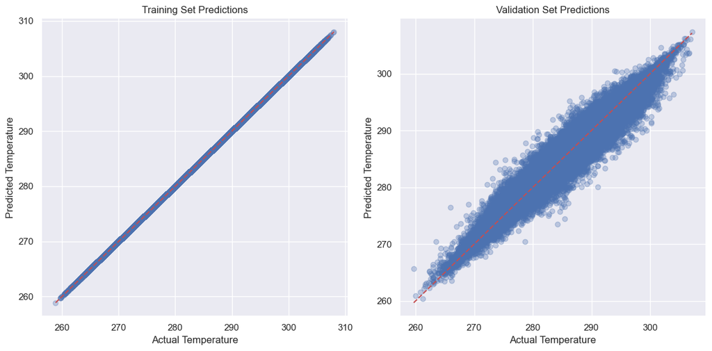

```python
# visualize error distributions
plt.figure(figsize=(12, 6))

plt.subplot(1, 2, 1)
plt.scatter(y_train, train_predictions, alpha=0.3)
plt.plot([y_train.min(), y_train.max()], [y_train.min(), y_train.max()], 'r--')
plt.xlabel('Actual Temperature')
plt.ylabel('Predicted Temperature')
plt.title('Training Set Predictions')

plt.subplot(1, 2, 2)
plt.scatter(y_val, val_predictions, alpha=0.3)
plt.plot([y_val.min(), y_val.max()], [y_val.min(), y_val.max()], 'r--')
plt.xlabel('Actual Temperature')
plt.ylabel('Predicted Temperature')
plt.title('Validation Set Predictions')

plt.tight_layout()
plt.show()
```

We will create a sample of 5% of our train data to reduce computational cost of tuning / searching for best parameters.

- n_neighbors: testing 3, 5, and 7 neighbors to find the optimal size
- leaf_size: testing 10 and 20
- p: testing distance metrics - 1 is Manhattan distance and 2 is Euclidean distance.

GridSearchCV tests all parameter combinations (12 total) using:

- 2-fold cross-validation (cv=2)
- neg_mean_squared_error as the key metric
- parallel processing (n_jobs=2)
- distance weight (kept constant)

As a result, our best parameters are:

- leaf_size=10:
- n_neighbors=5
- p=2 Euclidean distance works best

```python
# create samples for tuning
X_sample, _, y_sample, _ = train_test_split(
    X_train_pca, y_train, test_size=0.95, random_state=42
)
```

```python
# hyperparameter tuning on sample data
param_grid = {
    'n_neighbors': [3, 5, 7],
    'leaf_size': [10, 20],
    'p': [1, 2]
}

sample_grid_search = GridSearchCV(
    KNeighborsRegressor(algorithm='auto', weights='distance', n_jobs=2),
    param_grid,
    cv=2,
    scoring='neg_mean_squared_error',
    verbose=1
)
sample_grid_search.fit(X_sample, y_sample)
best_params = sample_grid_search.best_params_
print("Best parameters:", best_params)

# Fitting 2 folds for each of 12 candidates, totalling 24 fits
# Best parameters: {'leaf_size': 10, 'n_neighbors': 5, 'p': 2}
```

```
Fitting 2 folds for each of 12 candidates, totalling 24 fits
Best parameters: {'leaf_size': 10, 'n_neighbors': 5, 'p': 2}
```

We tested different weights, and distance proved to be best choice. Also we tested more number of neighbors and still n_neighbors = 5 proved the best.

```python
# weight parameters tuning
weight_param_grid = {
    'weights': ['uniform', 'distance'],
    'n_neighbors': [5, 9, 13, 17]
}

weight_grid_search = GridSearchCV(
    KNeighborsRegressor(algorithm='auto', leaf_size=10, p=2, n_jobs=2),
    weight_param_grid,
    cv=2,
    scoring='neg_mean_squared_error',
    verbose=1
)
weight_grid_search.fit(X_sample, y_sample)
print("Best weight parameters:", weight_grid_search.best_params_)

# Fitting 2 folds for each of 8 candidates, totalling 16 fits
# Best weighting parameters: {'n_neighbors': 5, 'weights': 'distance'}
```

```
Fitting 2 folds for each of 8 candidates, totalling 16 fits
Best weight parameters: {'n_neighbors': 5, 'weights': 'distance'}
```

We also checked different algorithms and our initial "auto" proved to be the best.

```python
# algorithms parameters tuning
algo_param_grid = {
    'algorithm': ['auto', 'ball_tree', 'kd_tree', 'brute'],
    'n_neighbors': [5, 7]
}

algo_grid_search = GridSearchCV(
    KNeighborsRegressor(weights='distance', leaf_size=10, p=2, n_jobs=2),
    algo_param_grid,
    cv=2,
    scoring='neg_mean_squared_error',
    verbose=1
)
algo_grid_search.fit(X_sample, y_sample)
print("Best algorithm parameters:", algo_grid_search.best_params_)

# Fitting 2 folds for each of 8 candidates, totalling 16 fits
# Best algorithm parameters: {'algorithm': 'auto', 'n_neighbors': 5}
```

```
Fitting 2 folds for each of 8 candidates, totalling 16 fits
Best algorithm parameters: {'algorithm': 'auto', 'n_neighbors': 5}
```

So, as a result of the fine-tuning we fitted and trained model with best parameters, that appeared to be almost equal to the initial default ones. Basically, the only thing that changed was leaf_size = 10 instead of 30. Hence, model's performance did not change comparing before the tuning. Most probably, KNN was already robust enough for this prediction task so that it was less sensitive for parameters tuning, also perhaps, our intuition for selecting parameters was confirmed, such as for selecting weight=distance, which was sensible given the data structure. Also, we fed KNN with nearby features, which the model would do by default, with given nearby features we basically set the priorities for the model. Even though, there is no straightforward way to extract which features were most important for KNN model’s prediction, our PCA confirmed that nearby features were valuable contributors. KNN’s trained on best hyperparameters achieved RMSE 0.5139 on validation and 0.5140 on test dataset, indicating strong predictive performance despite some overfitting. This means that this model predicts temperatures with average error of just 0.5139 of Kelvin unit, which is pretty accurate.

Otherwise, we could potentially try training model without dimensionality reduction, trying more number of parameters - but both cases are too computationally expensive and not feasible for our computer. We will fit other models to see if alternatives can perform well without overfitting.

```python
# fit and train KNN model with best parameters
best_knn = KNeighborsRegressor(
    n_neighbors=5,
    weights='distance',
    algorithm='auto',
    leaf_size=10,
    n_jobs=-1
)
best_knn.fit(X_train_pca, y_train)

best_train_predictions = best_knn.predict(X_train_pca)
best_val_predictions = best_knn.predict(X_val_pca)

best_train_mse = mean_squared_error(y_train, best_train_predictions)
best_train_rmse = np.sqrt(best_train_mse)
best_val_mse = mean_squared_error(y_val, best_val_predictions)
best_val_rmse = np.sqrt(best_val_mse)

print(f"Best model - Training RMSE: {best_train_rmse}")
print(f"Best model - Validation RMSE: {best_val_rmse}")
```

```
Best model - Training RMSE: 0.0
Best model - Validation RMSE: 0.5138869151979122
```

```python
# evaluate on test data
test_predictions = best_knn.predict(X_test_pca)
test_mse = mean_squared_error(y_test, test_predictions)
test_rmse = np.sqrt(test_mse)

print(f"Best model - Test RMSE: {test_rmse}")
```

```
Best model - Test RMSE: 0.5139996710826571
```

```python
# model performance summary
performance = pd.DataFrame({
    'Dataset': ['Training', 'Validation', 'Test'],
    'RMSE': [best_train_rmse, best_val_rmse, test_rmse],
    'MSE': [best_train_mse, best_val_mse, test_mse]
})
print(performance)
```

```
      Dataset      RMSE       MSE
0    Training  0.000000  0.000000
1  Validation  0.513887  0.264080
2        Test  0.514000  0.264196
```

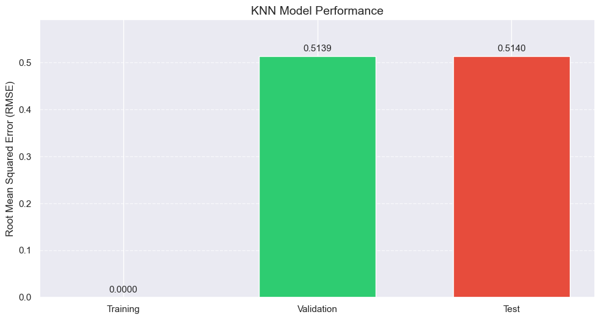

```python
# visualisation of KNN performance
plt.figure(figsize=(10, 6))

datasets = ['Training', 'Validation', 'Test']
rmse_values = [best_train_rmse, best_val_rmse, test_rmse]

bar_colors = ['#3498db', '#2ecc71', '#e74c3c']
bars = plt.bar(datasets, rmse_values, color=bar_colors, width=0.6)

for bar in bars:
    height = bar.get_height()
    plt.text(bar.get_x() + bar.get_width()/2., height + 0.01,
             f'{height:.4f}', ha='center', fontsize=11)

plt.grid(axis='y', linestyle='--', alpha=0.7)
plt.title('KNN Model Performance', fontsize=14)
plt.ylabel('Root Mean Squared Error (RMSE)', fontsize=12)
plt.ylim(0, max(rmse_values) * 1.15)


plt.tight_layout(rect=[0, 0.05, 1, 0.95])
plt.show()
```

### Random Forest Regressor

We chose a Random Forest Regressor, an ensemble method that averages the outputs of multiple decision trees.

This approach is particularly well-suited to our system, as it effectively handles complex, non-linear relationships between environmental features while minimizing the impact of less informative variables. Although individual trees are prone to overfitting, combining their outputs significantly reduces this risk as is seen by this model's low RMSE value.

```python
# Import necessary modules

import sklearn.tree
from sklearn.ensemble import RandomForestRegressor
from sklearn.tree import plot_tree
from sklearn.metrics import make_scorer, mean_squared_error, r2_score

from sklearn.model_selection import GridSearchCV
from sklearn.model_selection import RandomizedSearchCV
from scipy.stats import randint
```

We generate a single tree plot to better visualise how the model will prioritise data.

Our Forest is will be composed of an ensemble of these trees.

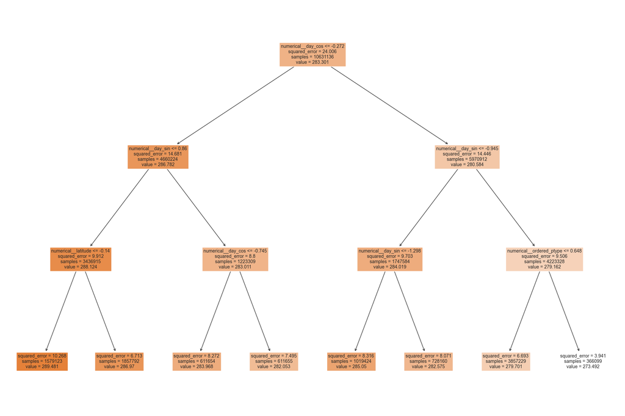

[output not shown]

```python
tree_depth1 = sklearn.tree.DecisionTreeRegressor(max_depth=3)
tree_depth1.fit(training_cleaned, target_training);

# Visualise the model.
plt.figure(figsize=(24, 16))
sklearn.tree.plot_tree(tree_depth1, feature_names=training_cleaned.columns, filled=True)
plt.show()
plt.close()
```

Now we generate a single random Forest and assess its performanceas a trial run. This Forest is large and will have the following hyperparameters:

```python
# Define Regression Model

forest_regressor = RandomForestRegressor(n_estimators=100, random_state=10, n_jobs = -1, oob_score=True)
forest_regressor.fit(training_cleaned, target_training)
```

```python
# First we compare attribute importance

for name, score in zip(training_cleaned.columns, forest_regressor.feature_importances_):
    print(f"The attribute {name} has an importance to the model of: {score:.3g}")
```

```
The attribute numerical__month_sin has an importance to the model of: 0.000627
The attribute numerical__month_cos has an importance to the model of: 0.000595
The attribute numerical__day_sin has an importance to the model of: 0.279
The attribute numerical__day_cos has an importance to the model of: 0.43
The attribute numerical__hour_sin has an importance to the model of: 0.0213
The attribute numerical__hour_cos has an importance to the model of: 0.0185
The attribute numerical__latitude has an importance to the model of: 0.0577
The attribute numerical__longitude has an importance to the model of: 0.025
The attribute numerical__tp has an importance to the model of: 0.0051
The attribute numerical__sp has an importance to the model of: 0.0349
The attribute numerical__u100 has an importance to the model of: 0.00858
The attribute numerical__v100 has an importance to the model of: 0.0161
The attribute numerical__tcc has an importance to the model of: 0.00778
The attribute numerical__ordered_ptype has an importance to the model of: 0.0563
The attribute numerical__wind_speed has an importance to the model of: 0.0131
The attribute numerical__wind_direction_sin has an importance to the model of: 0.00499
The attribute numerical__wind_direction_cos has an importance to the model of: 0.00611
The attribute numerical__historic_local_wind_speed has an importance to the model of: 0.00732
The attribute numerical__historic_local_precipitation has an importance to the model of: 0.00757
```

```python
# Find the performance metrics of our forest (on the training set)
oob_score = forest_regressor.oob_score_
print(f'Out-of-Bag Score: {oob_score:.4g}')

predictions = forest_regressor.predict(training_cleaned)

training_mse = mean_squared_error(target_training, predictions)
training_rmse = np.sqrt(training_mse)
print(f'Training Data Root Mean Squared Error: {training_rmse:.4g}')

med_temp = np.median(target_training)

print(f"Root Mean Squared Error for training data as a percentage of median: {(training_rmse / med_temp)*100:.4g}")

training_r2 = r2_score(target_training, predictions)
print(f'R Squared: {training_r2:.4g}')
```

```
Out-of-Bag Score: 0.9955
Training Data Root Mean Squared Error: 0.1214
Root Mean Squared Error for training data as a percentage of median: 0.04286
R Squared: 0.9994
```

```python
# Now find the performance on the tuning set

tuning_predictions = forest_regressor.predict(tuning_cleaned)

tuning_predictions = forest_regressor.predict(tuning_cleaned)

tuning_mse = mean_squared_error(target_tuning, tuning_predictions)
tuning_rmse = np.sqrt(tuning_mse)
print(f'Tuning Data Root Mean Squared Error: {tuning_rmse: .4g}')

med_temp = np.median(target_tuning)

print(f"Root Mean Squared Error for training data as a percentage of median: {(tuning_rmse / med_temp)*100:.4g}")

tuning_r2 = r2_score(target_tuning, tuning_predictions)
print(f'R Squared: {tuning_r2:.4g}')
```

```
Tuning Data Root Mean Squared Error:  0.5228
Root Mean Squared Error for training data as a percentage of median: 0.1846
R Squared: 0.9886
```

Here we again see a very low rmse value relative to the median temperature. This suggests that the splitting of the dataset was imperfect as the model appears to still be quite overfit.

This is because the original data set is dense in time and space, this means that for any point we have removed, we still have nearby spacial and temporal values for temperature. Thus, it appears that our model is currently tightly fit to the 2018 weather data and that our tuning is likely to further this. However, we still elect to proceed and we will analyse the reality of this later when we have applied a model to the test set.

Now we will perform a Randomised search on various possible Random Forest models to seek the best permutation of parameters.

```python
# Sample the data
x_sample = training_cleaned.sample(frac=0.01, random_state=10)
y_sample = target_training.sample(frac=0.01, random_state=10)

param_dist = {
    'n_estimators': [20, 50, 100],
    'max_depth': [5, 10, 15, None],
    'min_samples_split': [2, 5, 10],
    'min_samples_leaf': [1, 2, 4, 8],
    'max_features': ['sqrt']
}

random_search = RandomizedSearchCV(
    estimator=RandomForestRegressor(random_state=10),
    param_distributions=param_dist,
    n_iter=20,
    scoring='neg_root_mean_squared_error',
    cv=4,
    n_jobs=1,
    verbose=2,
    random_state=10
)

random_search.fit(x_sample, y_sample)
print("Best Random Search Parameters:", random_search.best_params_, '\nGiving a score of:', random_search.best_score_)
```

```
Fitting 4 folds for each of 20 candidates, totalling 80 fits
[CV] END max_depth=15, max_features=sqrt, min_samples_leaf=8, min_samples_split=2, n_estimators=20; total time=   3.0s
[CV] END max_depth=15, max_features=sqrt, min_samples_leaf=8, min_samples_split=2, n_estimators=20; total time=   2.9s
[CV] END max_depth=15, max_features=sqrt, min_samples_leaf=8, min_samples_split=2, n_estimators=20; total time=   3.0s
[CV] END max_depth=15, max_features=sqrt, min_samples_leaf=8, min_samples_split=2, n_estimators=20; total time=   2.9s
[CV] END max_depth=10, max_features=sqrt, min_samples_leaf=4, min_samples_split=10, n_estimators=20; total time=   2.3s
[CV] END max_depth=10, max_features=sqrt, min_samples_leaf=4, min_samples_split=10, n_estimators=20; total time=   2.2s
[CV] END max_depth=10, max_features=sqrt, min_samples_leaf=4, min_samples_split=10, n_estimators=20; total time=   2.3s
[CV] END max_depth=10, max_features=sqrt, min_samples_leaf=4, min_samples_split=10, n_estimators=20; total time=   2.2s
[CV] END max_depth=None, max_features=sqrt, min_samples_leaf=2, min_samples_split=2, n_estimators=100; total time=  18.1s
[CV] END max_depth=None, max_features=sqrt, min_samples_leaf=2, min_samples_split=2, n_estimators=100; total time=  18.0s
[CV] END max_depth=None, max_features=sqrt, min_samples_leaf=2, min_samples_split=2, n_estimators=100; total time=  18.4s
[CV] END max_depth=None, max_features=sqrt, min_samples_leaf=2, min_samples_split=2, n_estimators=100; total time=  18.4s
[CV] END max_depth=15, max_features=sqrt, min_samples_leaf=8, min_samples_split=5, n_estimators=50; total time=   7.5s
[CV] END max_depth=15, max_features=sqrt, min_samples_leaf=8, min_samples_split=5, n_estimators=50; total time=   7.3s
[CV] END max_depth=15, max_features=sqrt, min_samples_leaf=8, min_samples_split=5, n_estimators=50; total time=   7.4s
[CV] END max_depth=15, max_features=sqrt, min_samples_leaf=8, min_samples_split=5, n_estimators=50; total time=   7.2s
[CV] END max_depth=15, max_features=sqrt, min_samples_leaf=2, min_samples_split=2, n_estimators=100; total time=  15.2s
[CV] END max_depth=15, max_features=sqrt, min_samples_leaf=2, min_samples_split=2, n_estimators=100; total time=  15.5s
[CV] END max_depth=15, max_features=sqrt, min_samples_leaf=2, min_samples_split=2, n_estimators=100; total time=  15.7s
[CV] END max_depth=15, max_features=sqrt, min_samples_leaf=2, min_samples_split=2, n_estimators=100; total time=  15.4s
[CV] END max_depth=None, max_features=sqrt, min_samples_leaf=2, min_samples_split=5, n_estimators=20; total time=   3.6s
[CV] END max_depth=None, max_features=sqrt, min_samples_leaf=2, min_samples_split=5, n_estimators=20; total time=   3.6s
[CV] END max_depth=None, max_features=sqrt, min_samples_leaf=2, min_samples_split=5, n_estimators=20; total time=   3.7s
[CV] END max_depth=None, max_features=sqrt, min_samples_leaf=2, min_samples_split=5, n_estimators=20; total time=   3.5s
[CV] END max_depth=5, max_features=sqrt, min_samples_leaf=2, min_samples_split=2, n_estimators=50; total time=   3.1s
[CV] END max_depth=5, max_features=sqrt, min_samples_leaf=2, min_samples_split=2, n_estimators=50; total time=   3.1s
[CV] END max_depth=5, max_features=sqrt, min_samples_leaf=2, min_samples_split=2, n_estimators=50; total time=   3.1s
[CV] END max_depth=5, max_features=sqrt, min_samples_leaf=2, min_samples_split=2, n_estimators=50; total time=   3.0s
[CV] END max_depth=5, max_features=sqrt, min_samples_leaf=4, min_samples_split=10, n_estimators=20; total time=   1.3s
[CV] END max_depth=5, max_features=sqrt, min_samples_leaf=4, min_samples_split=10, n_estimators=20; total time=   1.3s
[CV] END max_depth=5, max_features=sqrt, min_samples_leaf=4, min_samples_split=10, n_estimators=20; total time=   1.2s
[CV] END max_depth=5, max_features=sqrt, min_samples_leaf=4, min_samples_split=10, n_estimators=20; total time=   1.4s
[CV] END max_depth=None, max_features=sqrt, min_samples_leaf=8, min_samples_split=2, n_estimators=50; total time=   7.4s
[CV] END max_depth=None, max_features=sqrt, min_samples_leaf=8, min_samples_split=2, n_estimators=50; total time=   7.7s
[CV] END max_depth=None, max_features=sqrt, min_samples_leaf=8, min_samples_split=2, n_estimators=50; total time=   8.0s
[CV] END max_depth=None, max_features=sqrt, min_samples_leaf=8, min_samples_split=2, n_estimators=50; total time=   7.4s
[CV] END max_depth=10, max_features=sqrt, min_samples_leaf=4, min_samples_split=5, n_estimators=50; total time=   5.5s
[CV] END max_depth=10, max_features=sqrt, min_samples_leaf=4, min_samples_split=5, n_estimators=50; total time=   5.4s
[CV] END max_depth=10, max_features=sqrt, min_samples_leaf=4, min_samples_split=5, n_estimators=50; total time=   5.8s
```

[output cut: 28 more lines]

```
[CV] END max_depth=5, max_features=sqrt, min_samples_leaf=4, min_samples_split=2, n_estimators=50; total time=   3.2s
[CV] END max_depth=10, max_features=sqrt, min_samples_leaf=8, min_samples_split=5, n_estimators=20; total time=   2.3s
[CV] END max_depth=10, max_features=sqrt, min_samples_leaf=8, min_samples_split=5, n_estimators=20; total time=   2.3s
[CV] END max_depth=10, max_features=sqrt, min_samples_leaf=8, min_samples_split=5, n_estimators=20; total time=   2.3s
[CV] END max_depth=10, max_features=sqrt, min_samples_leaf=8, min_samples_split=5, n_estimators=20; total time=   2.2s
[CV] END max_depth=10, max_features=sqrt, min_samples_leaf=8, min_samples_split=5, n_estimators=100; total time=  11.3s
[CV] END max_depth=10, max_features=sqrt, min_samples_leaf=8, min_samples_split=5, n_estimators=100; total time=  11.6s
[CV] END max_depth=10, max_features=sqrt, min_samples_leaf=8, min_samples_split=5, n_estimators=100; total time=  11.5s
[CV] END max_depth=10, max_features=sqrt, min_samples_leaf=8, min_samples_split=5, n_estimators=100; total time=  11.4s
[CV] END max_depth=None, max_features=sqrt, min_samples_leaf=8, min_samples_split=2, n_estimators=100; total time=  15.0s
[CV] END max_depth=None, max_features=sqrt, min_samples_leaf=8, min_samples_split=2, n_estimators=100; total time=  15.3s
[CV] END max_depth=None, max_features=sqrt, min_samples_leaf=8, min_samples_split=2, n_estimators=100; total time=  14.9s
[CV] END max_depth=None, max_features=sqrt, min_samples_leaf=8, min_samples_split=2, n_estimators=100; total time=  15.1s
Best Random Search Parameters: {'n_estimators': 100, 'min_samples_split': 2, 'min_samples_leaf': 2, 'max_features': 'sqrt', 'max_depth': None}
Giving a score of: -1.2262401964096696
```

From testing, we see that the initially chosen hyperparameters outperform those found to perform best from our search. As such, in the absense of a more thorough grid search which would require a significant increase in compute power, we shall stick with these.

We now apply these to the Validation Set and get a final RMSE:

```python
# Define Final Regression Model

final_forest_regressor = RandomForestRegressor(n_estimators=100, random_state=10, n_jobs = -1, oob_score=True, max_depth=None, min_samples_split=2, min_samples_leaf=1)
final_forest_regressor.fit(training_cleaned, target_training);

# final_forest_regressor.get_params()
```

```python
# Now find the performance on the validation set

validation_predictions = final_forest_regressor.predict(testing_cleaned)

validation_mse = mean_squared_error(target_testing, validation_predictions)
validation_rmse = np.sqrt(validation_mse)
print(f'The Root Mean Squared Error for our final Random Tree Model on the Validation Data is: {validation_rmse: .4g}')
```

```
The Root Mean Squared Error for our final Random Tree Model on the Validation Data is:  0.5207
```

Finally, after finding the numerical performance (RMSE) we plot the Predicitons vs Actuals, as well as the Residuals to better understand our model's weaknesses. We then see the general adherence to the correct prediction and the fact that the noise from the residuals appears random.

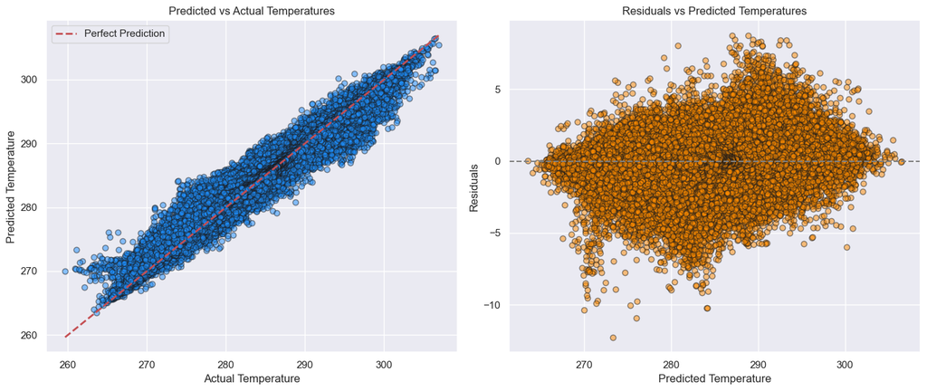

```python
# First calculate residuals
residuals = target_testing - validation_predictions

fig, axes = plt.subplots(1, 2, figsize=(14, 6))

# Predicted vs Actual
axes[0].scatter(target_testing, validation_predictions, alpha=0.5, color='dodgerblue', edgecolor='k')
axes[0].plot([target_testing.min(), target_testing.max()],
            [target_testing.min(), target_testing.max()],
            'r--', lw=2, label='Perfect Prediction')
axes[0].set_xlabel('Actual Temperature')
axes[0].set_ylabel('Predicted Temperature')
axes[0].set_title('Predicted vs Actual Temperatures')
axes[0].legend()
axes[0].grid(True)

# Residuals vs Predicted
axes[1].scatter(validation_predictions, residuals, alpha=0.5, color='darkorange', edgecolor='k')
axes[1].axhline(0, color='gray', linestyle='--')
axes[1].set_xlabel('Predicted Temperature')
axes[1].set_ylabel('Residuals')
axes[1].set_title('Residuals vs Predicted Temperatures')
axes[1].grid(True)

plt.tight_layout()
plt.show()
```

### *XGBoost*

We chose XGBoost for predicting temperature on this high-resolution weather dataset due to its strong performance with structured data and ability to capture complex nonlinear relationships. XGBoost supports regularization to reduce overfitting, and scales well with large datasets — both of which make it well-suited for the granular, feature-rich nature of weather data. Its flexibility and speed also make it ideal for efficient hyperparameter tuning and iterative experimentation.

```python
# Import required libraries

from sklearn.model_selection import RandomizedSearchCV  # for hyperparameter tuning
from sklearn.metrics import mean_squared_error   # to evaluate model performance
from xgboost import XGBRegressor   # for the XGBoost model
from scipy.stats import uniform, randint  # for parameter distributions
from sklearn.metrics import mean_squared_error, mean_absolute_error, r2_score   # for performance metrics
from math import sqrt
import matplotlib.pyplot as plt
import numpy as np
import seaborn as sns
```

```python
# Define the parameter distributions

param_distributions = {
    'n_estimators': randint(200, 300),   # number of trees (boosting rounds) - more improve performance, and computation time
    'max_depth': randint(2, 4),   # max depths of each tree - deeper tress capture more complex patterns, but can overfit
    'learning_rate': uniform(0.01, 0.3),   # controls how much the model adjusts after each tree - lower values can lead to better generalisation but need more trees
    'subsample': uniform(0.6, 1),   # the fraction of the data to use for fitting each tree - helps prevent overfitting
    'reg_alpha': uniform(0.1, 0.3),  # L1 regularization to prevent overfitting
    'reg_lambda': uniform(0, 0.5) # L2 regularization to prevent overfitting
}
```

```python
# Set up xgb

xgb = XGBRegressor(
    random_state=5059,
    n_jobs=1,   # use only 1 thread
    eval_metric='rmse'
)
```

```python
# Create RandomizedSearchCV object

# will test a specified number of random combos of hyperparameters in the param_distributions

random_search = RandomizedSearchCV(
    estimator=xgb,
    param_distributions=param_distributions,
    n_iter=30,
    scoring='neg_root_mean_squared_error',
    cv=3,
    verbose=3,
    n_jobs=2,
    random_state=5059
)
```

This will randomly sample 30 different combinations of hyperparameters from the specified param_distributions dictionary. For each combination, it will train the model using 3-fold cross-validation, scoring each run using negative RMSE (since scikit-learn minimizes score by default).

Arguments:

- estimator: the base XGBoost model (XGBRegressor) that we want to tune.
- param_distributions: dictionary defining the ranges/distributions from which hyperparameters will be randomly sampled.
- n_iter: number of random hyperparameter combinations to try (higher = more thorough search).
- scoring: the metric used to evaluate model performance during tuning. Here, we're using negative root mean squared error (neg_root_mean_squared_error), because lower RMSE = better.
- cv: number of folds in cross-validation (3-fold means the data is split into 3 subsets; the model is trained on 2 and validated on the 3rd, repeated 3 times with different splits).
- verbose: controls how much output is shown during fitting (3 = detailed progress).
- n_jobs: number of parallel jobs to run (2 = use 2 CPU cores; -1 would use all available).
- random_state: ensures reproducibility of the random sampling for consistent results.

```python
# Fit the random search

random_search.fit(training_cleaned, target_training)   # will try a specified number of combos of hyperparamters from param_distributions, evaluate and select best combo based on cv results
```

```
Fitting 3 folds for each of 30 candidates, totalling 90 fits
```

```
python(1770) MallocStackLogging: can't turn off malloc stack logging because it was not enabled.
python(1771) MallocStackLogging: can't turn off malloc stack logging because it was not enabled.
```

```
[CV 2/3] END learning_rate=0.20428927800279403, max_depth=3, n_estimators=292, reg_alpha=0.26152690575770154, reg_lambda=0.4509228119567833, subsample=1.230934526691064;, score=nan total time=  18.0s
[CV 1/3] END learning_rate=0.20428927800279403, max_depth=3, n_estimators=292, reg_alpha=0.26152690575770154, reg_lambda=0.4509228119567833, subsample=1.230934526691064;, score=nan total time=  18.0s
[CV 3/3] END learning_rate=0.20428927800279403, max_depth=3, n_estimators=292, reg_alpha=0.26152690575770154, reg_lambda=0.4509228119567833, subsample=1.230934526691064;, score=nan total time=   8.9s
[CV 1/3] END learning_rate=0.09052531608191072, max_depth=2, n_estimators=250, reg_alpha=0.26104696216505596, reg_lambda=0.314406585426303, subsample=1.197180119914227;, score=nan total time=   8.9s
[CV 2/3] END learning_rate=0.09052531608191072, max_depth=2, n_estimators=250, reg_alpha=0.26104696216505596, reg_lambda=0.314406585426303, subsample=1.197180119914227;, score=nan total time=   8.2s
[CV 3/3] END learning_rate=0.09052531608191072, max_depth=2, n_estimators=250, reg_alpha=0.26104696216505596, reg_lambda=0.314406585426303, subsample=1.197180119914227;, score=nan total time=   8.2s
[CV 2/3] END learning_rate=0.2140009598099779, max_depth=2, n_estimators=257, reg_alpha=0.29828056691535526, reg_lambda=0.3258561931148207, subsample=0.7975271848155395;, score=-5.142 total time=  49.3s
[CV 1/3] END learning_rate=0.2140009598099779, max_depth=2, n_estimators=257, reg_alpha=0.29828056691535526, reg_lambda=0.3258561931148207, subsample=0.7975271848155395;, score=-2.478 total time=  49.8s
[CV 1/3] END learning_rate=0.14173565555570647, max_depth=3, n_estimators=282, reg_alpha=0.11880958485416593, reg_lambda=0.07724130738639207, subsample=1.3840439105732791;, score=nan total time=   8.4s
[CV 2/3] END learning_rate=0.14173565555570647, max_depth=3, n_estimators=282, reg_alpha=0.11880958485416593, reg_lambda=0.07724130738639207, subsample=1.3840439105732791;, score=nan total time=   8.0s
[CV 3/3] END learning_rate=0.14173565555570647, max_depth=3, n_estimators=282, reg_alpha=0.11880958485416593, reg_lambda=0.07724130738639207, subsample=1.3840439105732791;, score=nan total time=   8.2s
```

[output not shown]

[output cut: 105 more lines]

[output not shown]

```python
# View best parameters and performance

print("Best parameters found:", random_search.best_params_)
print("Best cross-validated RMSE:", -random_search.best_score_)
```

[output not shown]

```python
# Get the best model
best_model = random_search.best_estimator_

# Access the best hyperparameters found
best_params = random_search.best_params_
```

```python
# Predict on validation set
validation_preds = best_model.predict(tuning_cleaned)

# Calculate RMSE
validation_rmse = sqrt(mean_squared_error(target_tuning, validation_preds))
print(f"Validation RMSE: {validation_rmse:.4f}")

validation_mae = mean_absolute_error(target_tuning, validation_preds)
print(f"Validation MAE: {validation_mae:.4f}")

validation_mape = np.mean(np.abs((target_tuning - validation_preds) / target_tuning)) * 100
print(f"Validation MAPE: {validation_mape:.2f}%")
```

```python
# Plot actual vs predicted values


plt.figure(figsize=(6, 6))
plt.scatter(target_tuning, validation_preds, alpha=0.6)
plt.plot([target_tuning.min(), target_tuning.max()],
        [target_tuning.min(), target_tuning.max()],
        'r--')
plt.xlabel("Actual Values")
plt.ylabel("Predicted Values")
plt.title("Validation Set: Actual vs Predicted")
plt.grid(True)
plt.show()
```

```python
# Calculate residuals

residuals = target_tuning - validation_preds
print(f"Mean residual: {residuals.mean():.4f}")
print(f"Std of residuals: {residuals.std():.4f}")
```

```python
# Residual plot

plt.figure(figsize=(8, 5))
plt.scatter(validation_preds, residuals, alpha=0.5)
plt.axhline(y=0, color='r', linestyle='--')
plt.xlabel("Predicted Values")
plt.ylabel("Residuals")
plt.title("Residual Plot")
plt.show()
```

```python
# Check out feature importance

importances = best_model.feature_importances_
features = tuning_cleaned.columns

sorted_idx = importances.argsort()
plt.figure(figsize=(8, 6))
plt.barh(features[sorted_idx], importances[sorted_idx])
plt.title("Feature Importance")
plt.xlabel("Importance Score")
plt.tight_layout()
plt.show()
```

```python
# Investigate why training CV RMSE is higher than validation RMSE by comparing the feature distributions between the training and validation sets
# to detect any distribution shift, data leakage, or imbalance that might make the validation set easier to predict

for col in training_cleaned.columns:
    sns.kdeplot(training_cleaned[col], label='Train')
    sns.kdeplot(tuning_cleaned[col], label='Validation')
    plt.title(col)
    plt.legend()
    plt.show()
```

### *Elastic Net*

```python
# Ensure all relevant libraries are imported
from sklearn.linear_model import ElasticNetCV
from sklearn.metrics import mean_squared_error
from sklearn.model_selection import learning_curve
import matplotlib.pyplot as plt
```

```python
# Candidate hyperparameter values
l1_ratio_values = np.linspace(0.1, 1.0, 10)
alpha_values = [1e-5, 1e-4, 1e-3, 1e-2, 1e-1, 0.0, 1.0, 10.0, 100.0]
```

In the case of this dataset, to find out to what degree the weighting should be allocated and also the intensity of the penalty applied we gave the training data to the ElasticNetCV model built into scikit-learn. This version of the model contains automatic hyperparameter tuning through cross-validation. This cross-validation performs on a par with traditional GridSearch validation but has the added advantage of reusing aspects of the model that were learned on previous attempts to fit it with different hyperparameter values. This can save significant processing time.

```python
# Train model and find best hyperparameter values
model = ElasticNetCV(l1_ratio=l1_ratio_values, alphas=alpha_values, cv=5)
results = model.fit(training_cleaned, target_training)
```

[output not shown]

```python
# separated hyperparameter calculation to avoid having to rerun fitting
mean_mse = model.mse_path_.mean(axis=2)
min_mse = mean_mse.min()
best_rmse = np.sqrt(min_mse)

print('Best alpha: ', model.alpha_)
print('Best l1_ratio_: ', model.l1_ratio_)
print('Best cross-validated RMSE: ', best_rmse)
```

```python
# Predict on validation data
predictions = model.predict(tuning_cleaned)

print("Validation RMSE: %f" % np.sqrt(mean_squared_error(target_tuning, predictions)))
```

```python
# plot the predicted values against the target data
def prediction_acc():
    xpoints = target_tuning
    ypoints = predictions
    fig, axes = plt.subplots()
    axes.set_xlabel("Target values /K ")
    axes.set_ylabel("Predicitons /K")
    axes.plot(xpoints, ypoints, 'bo', linestyle="None")
    z = np.polyfit(xpoints, ypoints, 1)
    p = np.poly1d(z)
    plt.plot(xpoints, p(xpoints), "r")

prediction_acc()
```

```python
residuals = target_tuning - predictions

# Plot of predicted results against residuals
def residuals_plt():
    xpoints = predictions
    ypoints = residuals
    fig, axes = plt.subplots()
    axes.set_xlabel("Predictions")
    axes.set_ylabel("Residuals")
    axes.plot(xpoints, ypoints, 'bo', linestyle="None")
    z = np.polyfit(xpoints, ypoints, 1)
    p = np.poly1d(z)
    plt.plot(xpoints, p(xpoints), "r")

residuals_plt()
```

```python
train_sizes, train_scores, val_scores = learning_curve(model, training_cleaned, target_training, cv=5, scoring='neg_root_mean_squared_error')
train_mean = -np.mean(train_scores, axis=1)
val_mean = -np.mean(val_scores, axis=1)

plt.figure(figsize=(6, 4))
plt.plot(train_sizes, train_mean, label="Training RMSE")
plt.plot(train_sizes, val_mean, label="Validation RMSE")
plt.xlabel("Training Set Size")
plt.ylabel("RMSE")
plt.title("Learning Curve")
plt.legend()
plt.show()
```

### *Model 5: Neural Networks*

```python
# Get list of independent variables
# X_features = training.columns();
X_features = ['numerical__month_sin', 'numerical__month_cos', 'numerical__day_sin',
       'numerical__day_cos', 'numerical__hour_sin', 'numerical__hour_cos',
       'numerical__latitude', 'numerical__longitude', 'numerical__tp',
       'numerical__sp', 'numerical__u100', 'numerical__v100', 'numerical__tcc',
       'numerical__ordered_ptype', 'numerical__wind_speed',
       'numerical__wind_direction_sin', 'numerical__wind_direction_cos',
       'numerical__historic_local_wind_speed',
       'numerical__historic_local_precipitation']

num_X_features = len(X_features)
```

#### Hyperparameters

```python
import inspect;

# Extract constructor from Net
from neural_net.net import Net;
empty_net = Net(num_X_features, "empty");
net_constructor = empty_net.__init__;

# Extract default values from constructor
default_args = inspect.signature(net_constructor);

# Print default values
print(default_args);
```

These are non-architectural hyperparameters that generally remain consistent between model architectures (with limited exceptions, e.g. gradient descent on the simpler model). Some hyperparameters are arbitrary constants chosen through inspection of training outputs, e.g. early stopping tolerance, while others define the optimisation method to choose an optimal hyperparameter, e.g. lr_start.

Batch size: number of samples processed before the model's parameters are updated. A large batch size helps smooth out gradient estimates and can improve throughput on modern GPUs with large memory capacities. I trained these models on a GTX 3080 Ti which meant I could use a large batch size. Although I trained this model on a powerful GPU, I had a very weak CPU which slowed down the training process considerably.

Output size: one neuron because we're producing a single prediction.

Optimiser: Regular gradient descent consistently produces constant improvements in loss, but spends too long in high-loss regions during testing. Adam is an optimiser that uses adaptive estimates of first and second moments, which reaches the low-loss region within 2–3 epochs but can't improve on these estimates further. AdaBound is an optimiser that uses Adam during the initial epochs to arrive at the low-loss regions, then gradually transitions its adaptive bounds toward those of stochastic gradient descent to produce steady improvements once in the low-loss area.

Adabound Gamma: the gamma parameter controls how quickly the adaptive learning-rate bounds widen during training. A smaller gamma keeps the bounds narrow for longer—closer to Adam’s behaviour—while a larger gamma allows a faster transition toward stochastic gradient descent, helping fine-grained convergence.

Criterion (Loss function): Mean Squared Error (MSE) measures the average of the squares of the errors between predictions and targets. It's widely used in regression tasks because it heavily penalises larger errors, encouraging the model to focus on reducing outliers.

lr_start: method of determining the starting learning rate. "range" means we use a learning-rate range test during the first epoch—cycling through a set of candidate rates—and then choose the rate which produced the greatest decrease in loss as the initial learning rate for subsequent training.

lr_scheduler (Plateau): this scheduler, often implemented as ReduceLROnPlateau, monitors a validation metric (e.g. validation loss) and reduces the learning rate by a given factor when no improvement is observed for a specified number of epochs. It helps the optimizer navigate plateaus in the loss landscape by taking smaller steps when approaching a minimum.

use_clipping: if True, gradients are clipped to a maximum norm before each update to prevent exploding gradients. This ensures that updates remain stable, especially in deep networks or when using high learning rates.

lr_factor: the factor by which the learning rate is multiplied when the scheduler triggers. A factor of 1 means no change, while a value less than 1 reduces the learning rate (e.g. 0.1 makes it ten times smaller).

normalise_y: when True, the target variable is scaled to zero mean and unit variance before training, and rescaled back when making predictions. Normalising targets stabilises and accelerates convergence, especially when the target’s scale differs significantly from input features.

early_stopping_tolerance: the minimum relative improvement in the monitored metric (e.g. validation loss) to qualify as an actual improvement. If the change in loss between epochs is less than this tolerance, it's considered as no improvement.

early_stopping_patience: the number of consecutive epochs for which the monitored metric can fail to improve beyond the tolerance before training is halted early. This prevents overfitting and saves computation once the model stops making meaningful progress.

#### Network Architecture

##### Simple Linear Net

```python
from neural_net.net_arch import SimpleLinearNet
simple_linear_net = SimpleLinearNet(num_X_features);
simple_linear_net.load();

simple_linear_net.get_info();
```

One neuron for each of our 19 features, all connecting to a single output neuron with a linear activation function.

We can inspect the weights and biases of this simple model to determine which features the model finds important.

```python
# Get output layer info from model
output_layer = simple_linear_net.get_final_layer(print_to_terminal = False);
simple_linear_net_weights = output_layer["_SimpleLinearNet__output_linear.weight"];

# Combine output layer and features
feature_weights = dict(zip(X_features, simple_linear_net_weights));

# Sort feature and weights map by absolute weight
feature_weights = {
    feature: weight
    for feature, weight in sorted(feature_weights.items(), key = lambda w: abs(w[1]), reverse = True)
}

# Print
for feature, weight in feature_weights.items():
    print(f"Feature: {feature}, weight: {weight}");
```

[output not shown]

There are a few discrepancies: longitude and wind direction aren't as important as they should be, because these are more complex relationships (e.g. longitude isn't significant by itself but needs to be combined with latitude to infer altitude, which is important).

```python
simple_linear_net.evaluate(testing, target_testing);
```

[figure not shown]

The model stopped training due to early stopping after four epochs, yet the loss curve doesn't look like it's approaching a minima yet. The early stopping scheme stops training too soon, as the model could learn more patterns without overfitting to noise. Four is the size of the early stopping window by default and is the minimum number of epochs that the model can go through. Therefore, early stopping is stopping training at the first chance it gets. This problem appears in all models, but retraining all models with a lower early stopping threshold is too computationally expensive.

The learning rate scheduler successfully recognises a plateau in loss reduction and decreases the learning rate to increase loss reduction, but early stopping means the model is not allowed to explore different weights and biases at this lower learning rate. Making early stopping less aggressive or enabling communication between the early stopping and the scheduler (e.g. prevent early stopping if learning rate has dropped) would address this.

This model appears to overpredict temperature (more points on left than right hand side of dotted line), and the model struggles at higher temperatures and tends to predict some mean high temperature instead. Adding model complexity should enable the model to address these flaws.

##### Single Layer Net

```python
from neural_net.net_arch import SingleLayerNet
single_relu_net = SingleLayerNet(num_X_features);
single_relu_net.load();

single_relu_net.get_info();
```

Single linear net: our 19 features goes into a hidden layer of 16 neurons, which then combine to produce our output (19 -> 16 -> 1).

```python
print(single_relu_net._SingleLayerNet__relu);
print("\n");

print(inspect.getsource(single_relu_net.forward));
```

We use a variant of the non-linear ReLU activation function between the hidden layer and the output layer to capture non-linearities. This "leaky" variant is one way of combatting neuron death.

ReLU outputs the input directly if it's positive and outputs zero if it's negative. This can lead to "dying ReLU" where neurons become inactive if they consistently receive negative inputs, as the gradient becomes zero. Leaky ReLU addresses this issue by allowing a small, non-zero gradient for negative inputs. Instead of outputting zero for negative inputs, it outputs a small, negative value (in our case, 0.01 * x).

```python
single_relu_net.evaluate(testing, target_testing);
```

[figure not shown]

As with the previous model, the early stopping kicks in too soon here. The learning rate scheduler encounters the same issues also, except the scheduler is never given the chance to drop the learning rate before early stopping takes effect.

##### Three layer net

```python
from neural_net.net_arch import ThreeLayerNet;
three_relu_net = ThreeLayerNet(num_X_features);
three_relu_net.load();

three_relu_net.get_info();
```

This net has a 19 -> 128 -> 64 -> 32 -> 1 structure.

```python
three_relu_net.evaluate(testing, target_testing);
```

Outperformed single-layer as expected.

[figure not shown]

As before, the model suffers from early stopping and learning rate scheduler issues.

The model now doesn't exhibit any biases, and strange outlier predictions that existed with previous models don't appear here.

##### Five layer net

```python
from neural_net.net_arch import FiveLayerNet;
five_relu_net = FiveLayerNet(num_X_features);
five_relu_net.load();

five_relu_net.get_info();
```

This net has a 19 -> 128 -> 64 -> 32 -> 16 -> 1 structure.

## Final Predictions Output

Having selected a final model we will now import the test data, process it, take only the longitude and latitude values which match the temperature data and export a file with our predicted temperatures.

```python
# Start by importing and processing the test data

file_name = 'test.csv'
data=pd.read_csv(file_name, sep=',')

# We will start by separating off only the valid_times at the latitude and longitude to use later in our predictions.csv file (saves recomputing from numerically scaled sin/cos)

formatted_predictions = data.query('latitude == 56.25 and longitude == -2.75')['valid_time']

formatted_predictions.head()
```

```
472     2019-01-01 00:00:00
1989    2019-01-01 01:00:00
3506    2019-01-01 02:00:00
5023    2019-01-01 03:00:00
6540    2019-01-01 04:00:00
Name: valid_time, dtype: object
```

```python
data.query('latitude == 56.25 and longitude == -2.75').head(n=10)
```

|  | id | valid_time | latitude | longitude | tp | u10 | v10 | sp | u100 | v100 | tcc | ptype |
| --- | --- | --- | --- | --- | --- | --- | --- | --- | --- | --- | --- | --- |
| 472 | 13289393 | 2019-01-01 00:00:00 | 56.25 | -2.75 | 0.000005 | 7.557495 | -1.296433 | 102183.125 | 11.391754 | -2.491272 | 0.244843 | 0.0 |
| 1989 | 13290910 | 2019-01-01 01:00:00 | 56.25 | -2.75 | 0.000004 | 5.734131 | -2.240692 | 102318.190 | 8.812622 | -3.929550 | 0.103882 | 0.0 |
| 3506 | 13292427 | 2019-01-01 02:00:00 | 56.25 | -2.75 | 0.000000 | 4.521027 | -2.533813 | 102486.560 | 7.029465 | -4.420135 | 0.010010 | 0.0 |
| 5023 | 13293944 | 2019-01-01 03:00:00 | 56.25 | -2.75 | 0.000000 | 4.191635 | -1.978699 | 102608.875 | 6.555008 | -3.649414 | 0.008392 | 0.0 |
| 6540 | 13295461 | 2019-01-01 04:00:00 | 56.25 | -2.75 | 0.000000 | 4.577438 | -0.976120 | 102667.060 | 7.365860 | -2.157288 | 0.000763 | 0.0 |
| 8057 | 13296978 | 2019-01-01 05:00:00 | 56.25 | -2.75 | 0.000000 | 5.000443 | -0.510193 | 102709.750 | 8.181229 | -1.572403 | 0.000000 | 0.0 |
| 9574 | 13298495 | 2019-01-01 06:00:00 | 56.25 | -2.75 | 0.000000 | 5.308579 | -0.502960 | 102779.690 | 8.558716 | -1.483719 | 0.000000 | 0.0 |
| 11091 | 13300012 | 2019-01-01 07:00:00 | 56.25 | -2.75 | 0.000000 | 5.321243 | -0.540649 | 102856.125 | 8.554810 | -1.559082 | 0.029694 | 0.0 |
| 12608 | 13301529 | 2019-01-01 08:00:00 | 56.25 | -2.75 | 0.000000 | 5.194733 | -0.520508 | 102981.875 | 8.244553 | -1.640167 | 0.038513 | 0.0 |
| 14125 | 13303046 | 2019-01-01 09:00:00 | 56.25 | -2.75 | 0.000000 | 4.885834 | -0.675095 | 103065.190 | 7.610138 | -2.023560 | 0.129089 | 0.0 |

```python
# Specify the features to keep for pipeline
columns_to_keep = ['valid_time', 'latitude', 'longitude', 'tp', 'sp', 'u100', 'v100', 'tcc', 'ptype']
numerical_attributes = ['month_sin', 'month_cos', 'day_sin', 'day_cos', 'hour_sin', 'hour_cos', 'latitude', 'longitude', 'tp', 'sp', 'u100', 'v100', 'tcc', 'ordered_ptype', 'wind_speed', 'wind_direction_sin', 'wind_direction_cos', 'historic_local_wind_speed', 'historic_local_precipitation']

# Define pipeline
full_pipeline = ColumnTransformer([
    ("numerical", StandardScaler(), numerical_attributes)
])
full_pipeline.set_output(transform="pandas")

# Generate the data pipeline for final test data

test = full_pipeline.fit_transform(clean_and_prep(data, columns_to_keep))
test.sample(n=20, random_state=10)
```

|  | numerical__month_sin | numerical__month_cos | numerical__day_sin | numerical__day_cos | numerical__hour_sin | numerical__hour_cos | numerical__latitude | numerical__longitude | numerical__tp | numerical__sp | numerical__u100 | numerical__v100 | numerical__tcc | numerical__ordered_ptype | numerical__wind_speed | numerical__wind_direction_sin | numerical__wind_direction_cos | numerical__historic_local_wind_speed | numerical__historic_local_precipitation |
| --- | --- | --- | --- | --- | --- | --- | --- | --- | --- | --- | --- | --- | --- | --- | --- | --- | --- | --- | --- |
| 6368684 | 0.007626 | -1.407976 | 0.182077 | -1.402444 | -7.071068e-01 | 1.224745e+00 | 1.030244 | 0.929670 | -0.374354 | 0.852693 | -0.298015 | -0.379167 | 0.888954 | -0.898770 | -1.785855 | -1.588210 | 0.221815 | -0.823592 | 0.100774 |
| 2787359 | 1.424796 | 0.003349 | 1.371878 | 0.343441 | -3.660254e-01 | -1.366025e+00 | 0.280976 | -0.422577 | 0.258468 | -1.229591 | 0.118406 | 0.347268 | 0.888954 | 0.384073 | -0.851086 | 0.934336 | 0.594137 | -0.415023 | 0.429758 |
| 11560465 | -0.700959 | 1.225591 | -1.023387 | 0.976053 | 1.637845e-16 | -1.414214e+00 | -0.374634 | 0.253546 | 0.307578 | -1.183688 | -1.543899 | -2.019357 | 0.888954 | 0.384073 | 1.217359 | -1.430909 | -1.138323 | 1.097928 | 1.174365 |
| 2437813 | 1.424796 | 0.003349 | 1.292772 | 0.573359 | -7.071068e-01 | 1.224745e+00 | -1.685854 | 1.267731 | 2.527365 | 0.278246 | 1.443864 | 1.853978 | 0.853648 | 0.384073 | 2.170236 | 0.893607 | 0.642833 | 1.844094 | 1.957939 |
| 6044851 | 0.007626 | -1.407976 | 0.372879 | -1.364170 | -9.406670e-18 | 1.414214e+00 | -0.842927 | -0.338062 | 0.052204 | -0.941784 | -0.123999 | 0.782330 | 0.888954 | 0.384073 | -0.410600 | 1.218315 | 0.001898 | -0.737374 | -0.422637 |
| 1293523 | 1.234931 | 0.709011 | 0.821376 | 1.151235 | 1.637845e-16 | -1.414214e+00 | -0.655610 | -0.507093 | 0.697654 | 0.751001 | -0.762324 | 1.923179 | 0.888954 | 0.384073 | 1.318469 | 1.225791 | -0.589499 | 1.266402 | 0.107824 |
| 1627685 | 1.234931 | 0.709011 | 0.989183 | 1.010701 | -1.224745e+00 | -7.071068e-01 | -1.592196 | 0.507093 | -0.377160 | 1.441383 | -1.162754 | 0.272375 | -2.092780 | -0.898770 | -0.526135 | 0.566342 | -1.544885 | -0.848705 | -0.473750 |
| 8985415 | -1.409544 | 0.003349 | -1.266908 | -0.628446 | -1.366025e+00 | 3.660254e-01 | 1.217562 | -0.084515 | 0.380542 | 0.396091 | 1.053463 | -2.208395 | -0.199623 | 0.384073 | 1.628017 | -1.408269 | 0.546638 | 0.987866 | 0.552170 |
| 297932 | 0.716211 | 1.225591 | 0.218226 | 1.397275 | 1.224745e+00 | 7.071068e-01 | 0.374634 | 0.507093 | -0.203169 | 1.331243 | -0.187362 | -2.429190 | 0.078914 | 0.384073 | 1.273486 | -1.686145 | -0.202854 | 1.238059 | -0.310745 |
| 13223147 | 0.007626 | 1.414673 | -0.024343 | 1.414004 | 1.224745e+00 | 7.071068e-01 | -0.468293 | 1.014185 | -0.377160 | 1.015661 | 0.850310 | 0.752792 | -1.287745 | -0.898770 | 0.368178 | 0.716608 | 0.813909 | 0.494187 | -0.470858 |
| 858896 | 0.716211 | 1.225591 | 0.567790 | 1.295228 | -7.071068e-01 | -1.224745e+00 | 1.123903 | 0.676123 | -0.365935 | 0.276055 | -0.004459 | -0.483938 | -1.621879 | -0.898770 | -1.364442 | -1.035867 | 0.900920 | -1.523139 | -0.427291 |
| 3015547 | 1.424796 | 0.003349 | 1.399976 | 0.200168 | -1.366025e+00 | 3.660254e-01 | -1.123903 | 1.521278 | -0.377160 | 1.319512 | 0.718967 | -0.878970 | -1.303214 | -0.898770 | -0.117604 | -0.955918 | 0.950225 | -0.554949 | -0.473750 |
| 7750340 | -1.219679 | -0.702314 | -0.708863 | -1.223729 | -1.224745e+00 | 7.071068e-01 | -1.685854 | 0.676123 | -0.377160 | 0.790644 | 0.275353 | -0.551899 | -1.569011 | -0.898770 | -0.943038 | -0.850124 | 1.005345 | -0.980574 | -0.463505 |
| 8566210 | -1.219679 | -0.702314 | -1.125973 | -0.855678 | 1.414214e+00 | 1.936199e-16 | -1.030244 | 1.605793 | -0.377160 | 0.927537 | -1.084307 | 0.230973 | -1.853007 | -0.898770 | -0.660023 | 0.576885 | -1.538233 | -0.874427 | -0.473750 |
| 7898769 | -1.219679 | -0.702314 | -0.791379 | -1.172058 | -7.071068e-01 | 1.224745e+00 | -1.123903 | 1.436762 | -0.377160 | 0.266938 | 0.903590 | 0.658780 | -0.112267 | -0.898770 | 0.346885 | 0.636706 | 0.874675 | -0.018726 | -0.467856 |
| 12847779 | 0.007626 | 1.414673 | -0.290062 | 1.384147 | -1.000000e+00 | 1.000000e+00 | 1.030244 | -0.084515 | 2.228494 | -4.055723 | -1.185393 | -0.012104 | 0.888954 | 0.384073 | -0.668750 | 0.178060 | -1.715734 | -0.380072 | 2.265745 |
| 13005150 | 0.007626 | 1.414673 | -0.170000 | 1.403959 | 1.224745e+00 | 7.071068e-01 | -1.498537 | 1.014185 | -0.215798 | 0.112909 | 1.792427 | 1.094870 | 0.864931 | 0.384073 | 1.834394 | 0.554847 | 0.928630 | 0.743813 | 2.179217 |
| 3339844 | 1.234931 | -0.702314 | 1.414096 | -0.018258 | -1.366025e+00 | -3.660254e-01 | -0.374634 | 0.422577 | -0.245264 | -1.966194 | 0.518316 | -0.611446 | -0.225011 | 0.384073 | -0.568898 | -0.776177 | 1.037714 | -0.750863 | 0.802309 |
| 847935 | 0.716211 | 1.225591 | 0.567790 | 1.295228 | 1.414214e+00 | 1.936199e-16 | -1.592196 | -0.507093 | -0.365935 | 0.111779 | -0.059676 | -0.371933 | 0.888954 | 0.384073 | -1.518126 | -0.780958 | 1.035766 | -1.092249 | -0.419029 |
| 9771517 | -1.409544 | 0.003349 | -1.409489 | -0.115508 | 1.000000e+00 | -1.000000e+00 | 0.561951 | 0.676123 | -0.270521 | -0.587440 | 0.284121 | 1.035313 | -0.789727 | 0.384073 | 0.157306 | 1.097519 | 0.340143 | 1.052782 | 0.997976 |

```python
# We now select only the data at the specific latitude and longitude of 56.25 and -2.75 (These will have been modified in value by our numerical scaler, so we will need to set the values as the scaled ones found by taking the corresponding indeces to those found before)

specific_test = test.query(f'numerical__latitude == {test.loc[472]['numerical__latitude']} and numerical__longitude == {test.loc[472]['numerical__longitude']}')

specific_test.head(n=10)
```

|  | numerical__month_sin | numerical__month_cos | numerical__day_sin | numerical__day_cos | numerical__hour_sin | numerical__hour_cos | numerical__latitude | numerical__longitude | numerical__tp | numerical__sp | numerical__u100 | numerical__v100 | numerical__tcc | numerical__ordered_ptype | numerical__wind_speed | numerical__wind_direction_sin | numerical__wind_direction_cos | numerical__historic_local_wind_speed | numerical__historic_local_precipitation |
| --- | --- | --- | --- | --- | --- | --- | --- | --- | --- | --- | --- | --- | --- | --- | --- | --- | --- | --- | --- |
| 472 | 0.716211 | 1.225591 | 0.024343 | 1.414004 | -9.406670e-18 | 1.414214e+00 | 0.65561 | 0.084515 | -0.363129 | 0.998030 | 1.426431 | -0.645556 | -1.362725 | -0.89877 | 0.770041 | -0.533124 | 1.112717 | -2.148803 | -0.473750 |
| 1989 | 0.716211 | 1.225591 | 0.024343 | 1.414004 | 3.660254e-01 | 1.366025e+00 | 0.65561 | 0.084515 | -0.364532 | 1.074391 | 1.024782 | -0.873452 | -1.783032 | -0.89877 | 0.293481 | -0.818016 | 1.019992 | 1.031786 | -0.462128 |
| 3506 | 0.716211 | 1.225591 | 0.024343 | 1.414004 | 7.071068e-01 | 1.224745e+00 | 0.65561 | 0.084515 | -0.377160 | 1.169582 | 0.747090 | -0.951186 | -2.062933 | -0.89877 | -0.025184 | -1.002046 | 0.922639 | 0.757115 | -0.468572 |
| 5023 | 0.716211 | 1.225591 | 0.024343 | 1.414004 | 1.000000e+00 | 1.000000e+00 | 0.65561 | 0.084515 | -0.377160 | 1.238735 | 0.673203 | -0.829064 | -2.067756 | -0.89877 | -0.214971 | -0.934534 | 0.962255 | 0.488554 | -0.471684 |
| 6540 | 0.716211 | 1.225591 | 0.024343 | 1.414004 | 1.224745e+00 | 7.071068e-01 | 0.65561 | 0.084515 | -0.377160 | 1.271631 | 0.799477 | -0.592636 | -2.090505 | -0.89877 | -0.174030 | -0.632345 | 1.087602 | 0.268193 | -0.471987 |
| 8057 | 0.716211 | 1.225591 | 0.024343 | 1.414004 | 1.366025e+00 | 3.660254e-01 | 0.65561 | 0.084515 | -0.377160 | 1.295766 | 0.926455 | -0.499961 | -2.092780 | -0.89877 | -0.018720 | -0.496484 | 1.120175 | 0.163988 | -0.471712 |
| 9574 | 0.716211 | 1.225591 | 0.024343 | 1.414004 | 1.414214e+00 | 1.936199e-16 | 0.65561 | 0.084515 | -0.377160 | 1.335308 | 0.985241 | -0.485909 | -2.092780 | -0.89877 | 0.065463 | -0.470097 | 1.124953 | 0.161290 | -0.471381 |
| 11091 | 0.716211 | 1.225591 | 0.024343 | 1.414004 | 1.366025e+00 | -3.660254e-01 | 0.65561 | 0.084515 | -0.377160 | 1.378522 | 0.984633 | -0.497850 | -2.004241 | -0.89877 | 0.067677 | -0.482580 | 1.122754 | 0.175344 | -0.468242 |
| 12608 | 0.716211 | 1.225591 | 0.024343 | 1.414004 | 1.224745e+00 | -7.071068e-01 | 0.65561 | 0.084515 | -0.377160 | 1.449617 | 0.936316 | -0.510698 | -1.977944 | -0.89877 | -0.000919 | -0.505863 | 1.118357 | 0.181276 | -0.414650 |
| 14125 | 0.716211 | 1.225591 | 0.024343 | 1.414004 | 1.000000e+00 | -1.000000e+00 | 0.65561 | 0.084515 | -0.377160 | 1.496721 | 0.837518 | -0.571447 | -1.707870 | -0.89877 | -0.126821 | -0.596887 | 1.097417 | 0.143493 | -0.409804 |

```python
# We see that this contains the 8760 entries with indeces corresponding to those of our initial query.

specific_test.info()
```

```
<class 'pandas.core.frame.DataFrame'>
Index: 8760 entries, 472 to 13287875
Data columns (total 19 columns):
 #   Column                                   Non-Null Count  Dtype
---  ------                                   --------------  -----
 0   numerical__month_sin                     8760 non-null   float64
 1   numerical__month_cos                     8760 non-null   float64
 2   numerical__day_sin                       8760 non-null   float64
 3   numerical__day_cos                       8760 non-null   float64
 4   numerical__hour_sin                      8760 non-null   float64
 5   numerical__hour_cos                      8760 non-null   float64
 6   numerical__latitude                      8760 non-null   float64
 7   numerical__longitude                     8760 non-null   float64
 8   numerical__tp                            8760 non-null   float64
 9   numerical__sp                            8760 non-null   float64
 10  numerical__u100                          8760 non-null   float64
 11  numerical__v100                          8760 non-null   float64
 12  numerical__tcc                           8760 non-null   float64
 13  numerical__ordered_ptype                 8760 non-null   float64
 14  numerical__wind_speed                    8760 non-null   float64
 15  numerical__wind_direction_sin            8760 non-null   float64
 16  numerical__wind_direction_cos            8760 non-null   float64
 17  numerical__historic_local_wind_speed     8760 non-null   float64
 18  numerical__historic_local_precipitation  8760 non-null   float64
dtypes: float64(19)
memory usage: 1.3 MB
```

Now we produce the Final Predictions using our selected Model.

```python
# Now we make predictions on our sample data

final_pca = pca.transform(specific_test) # As we used PCA for oue KNN model, we need to do this here.

final_model = best_knn # We selected the KNN model as our final solution due to thlow RMSE value and comparitively efficient run time.

final_predictions = np.array(final_model.predict(final_pca))
```

```python
# Check that the predicted array is the correct length
print(len(formatted_predictions), len(final_predictions))
```

```
8760 8760
```

```python
# Convert the valid_time Series to a DataFrame
formatted_predictions = pd.DataFrame({'valid_time': formatted_predictions})

# Then add the predictions
formatted_predictions['predictions'] = final_predictions
```

```python
# Quick sanity check of the shape and values
print(formatted_predictions)
```

```
                   valid_time  predictions
472       2019-01-01 00:00:00   277.286177
1989      2019-01-01 01:00:00   279.189476
3506      2019-01-01 02:00:00   278.722319
5023      2019-01-01 03:00:00   278.452356
6540      2019-01-01 04:00:00   277.885796
...                       ...          ...
13281807  2019-12-31 19:00:00   276.569238
13283324  2019-12-31 20:00:00   277.775056
13284841  2019-12-31 21:00:00   279.869078
13286358  2019-12-31 22:00:00   282.021979
13287875  2019-12-31 23:00:00   282.096434

[8760 rows x 2 columns]
```

Finally, we export our predictions to a csv file.

```python
formatted_predictions.columns = ['valid_time', 'predictions']
formatted_predictions.to_csv("temperature_predictions.csv", index=False)
```